# Diss cleaning

```r
# Get the number and percentage of participants who chose
# each researcher for each attribute and vignette

attribute_descriptives = attr_model_dat %>%
  group_by(vignette_id, severity_num, attribute, researcher_ec) %>%
  summarise(
    N = sum(chosen == 1, na.rm = TRUE),
    .groups = "drop"
  ) %>%
  group_by(vignette_id, severity_num, attribute) %>%
  mutate(
    Total_N = sum(N),
    Percent = round(N / Total_N * 100, 2)
  ) %>%
  tidyr::pivot_wider(
    names_from = researcher_ec,
    values_from = c(N, Percent),
    values_fill = 0,
    names_glue = "{.value}_{researcher_ec}"
  ) %>%
  rename(
    Investigator_N = `N_-1`,
    Inspector_N = `N_1`,
    Investigator_Percent = `Percent_-1`,
    Inspector_Percent = `Percent_1`
  ) %>%
  ungroup()

print(attribute_descriptives, n = 27)
```

```
## # A tibble: 27 × 8
##    vignette_id severity_num attribute         Total_N Investigator_N Inspector_N
##    <fct>              <dbl> <fct>               <int>          <int>       <int>
##  1 minor                  0 smarter               246             58         188
##  2 minor                  0 better_researcher     335             47         288
##  3 minor                  0 creative              253            142         111
##  4 minor                  0 rather_be             338             69         269
##  5 minor                  0 should_be             344             41         303
##  6 minor                  0 celebrated            360             81         279
##  7 minor                  0 typical               356            211         145
##  8 minor                  0 job_security          363             68         295
##  9 minor                  0 job_outcome           365            106         259
## 10 moderate               1 smarter               267             30         237
## 11 moderate               1 better_researcher     359             23         336
## 12 moderate               1 creative              251            145         106
```

[output cut: 16 more lines]

```r
### 5. Overall attribute test + pairwise comparisons

# Test the overall effect of attribute

anova(A4, test = "Chisq")
```

```
## Analysis of Variance Table
##                            npar Sum Sq Mean Sq   F value
## researcher_ec                 1 4720.4  4720.4 4720.3845
## severity_num                  1    7.7     7.7    7.6998
## attribute                     8  357.0    44.6   44.6194
## researcher_ec:severity_num    1  432.5   432.5  432.5269
```

```r
# Get estimated marginal means for each attribute

library(emmeans)
attribute_emmeans = emmeans(
  A4,
  ~ attribute,
  type = "response"
)

print(attribute_emmeans)
```

```
##  attribute          prob      SE  df asymp.LCL asymp.UCL
##  smarter           0.230 0.01030 Inf     0.211     0.251
##  better_researcher 0.351 0.01280 Inf     0.327     0.377
##  creative          0.204 0.00953 Inf     0.186     0.224
##  rather_be         0.343 0.01270 Inf     0.319     0.369
##  should_be         0.370 0.01310 Inf     0.345     0.396
##  celebrated        0.381 0.01320 Inf     0.356     0.407
##  typical           0.326 0.01240 Inf     0.302     0.350
##  job_security      0.401 0.01340 Inf     0.375     0.427
##  job_outcome       0.391 0.01330 Inf     0.366     0.418
##
## Results are averaged over the levels of: researcher_ec
## Confidence level used: 0.95
## Intervals are back-transformed from the logit scale
```

```r
# Compare attributes to each other

pairs(
  attribute_emmeans,
  adjust = "bonferroni"
)
```

```
##  contrast                         odds.ratio     SE  df null z.ratio p.value
##  smarter / better_researcher           0.552 0.0378 Inf    1  -8.680 <0.0001
##  smarter / creative                    1.162 0.0812 Inf    1   2.150  1.0000
##  smarter / rather_be                   0.571 0.0391 Inf    1  -8.179 <0.0001
##  smarter / should_be                   0.508 0.0348 Inf    1  -9.878 <0.0001
##  smarter / celebrated                  0.485 0.0332 Inf    1 -10.574 <0.0001
##  smarter / typical                     0.619 0.0424 Inf    1  -7.003 <0.0001
##  smarter / job_security                0.447 0.0306 Inf    1 -11.760 <0.0001
##  smarter / job_outcome                 0.464 0.0318 Inf    1 -11.201 <0.0001
##  better_researcher / creative          2.106 0.1450 Inf    1  10.789 <0.0001
##  better_researcher / rather_be         1.035 0.0697 Inf    1   0.508  1.0000
##  better_researcher / should_be         0.921 0.0620 Inf    1  -1.217  1.0000
##  better_researcher / celebrated        0.879 0.0591 Inf    1  -1.925  1.0000
##  better_researcher / typical           1.121 0.0756 Inf    1   1.696  1.0000
##  better_researcher / job_security      0.810 0.0544 Inf    1  -3.136  0.0616
##  better_researcher / job_outcome       0.842 0.0566 Inf    1  -2.565  0.3717
##  creative / rather_be                  0.491 0.0339 Inf    1 -10.292 <0.0001
##  creative / should_be                  0.438 0.0302 Inf    1 -11.978 <0.0001
##  creative / celebrated                 0.417 0.0288 Inf    1 -12.667 <0.0001
##  creative / typical                    0.532 0.0368 Inf    1  -9.125 <0.0001
##  creative / job_security               0.385 0.0265 Inf    1 -13.842 <0.0001
##  creative / job_outcome                0.400 0.0276 Inf    1 -13.288 <0.0001
##  rather_be / should_be                 0.890 0.0599 Inf    1  -1.725  1.0000
##  rather_be / celebrated                0.849 0.0571 Inf    1  -2.433  0.5398
##  rather_be / typical                   1.083 0.0731 Inf    1   1.188  1.0000
##  rather_be / job_security              0.783 0.0526 Inf    1  -3.643  0.0097
##  rather_be / job_outcome               0.813 0.0547 Inf    1  -3.072  0.0765
##  should_be / celebrated                0.954 0.0640 Inf    1  -0.708  1.0000
##  should_be / typical                   1.217 0.0820 Inf    1   2.911  0.1296
##  should_be / job_security              0.879 0.0590 Inf    1  -1.921  1.0000
##  should_be / job_outcome               0.913 0.0613 Inf    1  -1.349  1.0000
##  celebrated / typical                  1.276 0.0859 Inf    1   3.618  0.0107
##  celebrated / job_security             0.922 0.0618 Inf    1  -1.213  1.0000
##  celebrated / job_outcome              0.958 0.0643 Inf    1  -0.640  1.0000
##  typical / job_security                0.723 0.0486 Inf    1  -4.828 <0.0001
##  typical / job_outcome                 0.751 0.0506 Inf    1  -4.257  0.0007
##  job_security / job_outcome            1.039 0.0696 Inf    1   0.572  1.0000
##
## Results are averaged over the levels of: researcher_ec
## P value adjustment: bonferroni method for 36 tests
## Tests are performed on the log odds ratio scale
```

###table

```r
# Create APA-style table of researcher choices by attribute and severity

attribute_table = attribute_descriptives %>%
  mutate(
    Investigator = paste0(
      Investigator_N, " (", Investigator_Percent, "%)"
    ),
    Inspector = paste0(
      Inspector_N, " (", Inspector_Percent, "%)"
    )
  ) %>%
  select(
    severity = vignette_id,
    attribute,
    Investigator,
    Inspector
  ) %>%
  tidyr::pivot_wider(
    names_from = severity,
    values_from = c(Investigator, Inspector)
  ) %>%
  select(
    attribute,
    Investigator_minor,
    Inspector_minor,
    Investigator_moderate,
    Inspector_moderate,
    Investigator_major,
    Inspector_major
  )

knitr::kable(
  attribute_table,
  caption = "Researcher Selections for Positive Attributes by QRP Severity",
  col.names = c(
    "Attribute",
    "Investigator",
    "Inspector",
    "Investigator",
    "Inspector",
    "Investigator",
    "Inspector"
  ),
  align = c("l", "c", "c", "c", "c", "c", "c")
)
```

Researcher Selections for Positive Attributes by QRP Severity

| Attribute | Investigator | Inspector | Investigator | Inspector | Investigator | Inspector |
| --- | --- | --- | --- | --- | --- | --- |
| smarter | 58 (23.58%) | 188 (76.42%) | 30 (11.24%) | 237 (88.76%) | 16 (5.37%) | 282 (94.63%) |
| better_researcher | 47 (14.03%) | 288 (85.97%) | 23 (6.41%) | 336 (93.59%) | 12 (3.23%) | 359 (96.77%) |
| creative | 142 (56.13%) | 111 (43.87%) | 145 (57.77%) | 106 (42.23%) | 124 (50.41%) | 122 (49.59%) |
| rather_be | 69 (20.41%) | 269 (79.59%) | 18 (5.07%) | 337 (94.93%) | 14 (3.92%) | 343 (96.08%) |
| should_be | 41 (11.92%) | 303 (88.08%) | 10 (2.65%) | 368 (97.35%) | 11 (2.9%) | 368 (97.1%) |
| celebrated | 81 (22.5%) | 279 (77.5%) | 41 (10.65%) | 344 (89.35%) | 26 (6.9%) | 351 (93.1%) |
| typical | 211 (59.27%) | 145 (40.73%) | 145 (42.9%) | 193 (57.1%) | 112 (34.89%) | 209 (65.11%) |
| job_security | 68 (18.73%) | 295 (81.27%) | 29 (7.29%) | 369 (92.71%) | 18 (4.53%) | 379 (95.47%) |
| job_outcome | 106 (29.04%) | 259 (70.96%) | 54 (14.06%) | 330 (85.94%) | 34 (8.67%) | 358 (91.33%) |

# Integrity & LIKEABILITY ANALYSIS (RQ1, RQ2) + TRUENESS (RQ3)

Research Question 1: How is integrity influenced by role and QRP severity? • Hypothesis 1a: Inspectors will be rated higher in integrity than investigators. • Hypothesis 1b: The relative integrity of inspectors versus investigators will increase as QRP severity increases.

Research Question 2: How is likeability influenced by role and QRP severity? • Hypothesis 2a: Investigators will be rated more likable than inspectors. • Hypothesis 2b: At low QRP severity, investigators will be rated as more likeable than inspectors, but at high QRP severity, inspectors will be rated as more likeable than investigators.

Research Question 3: Is the perceived trueness of the finding influenced by QRP severity? • Hypothesis 3: Perceived trueness will decrease as QRP severity increases.

Research Questions 1–2: Integrity and Likeability Step-up MLMs will test Role, Severity, and Role × Severity interaction:

Model 1: Integrity/Likeabilityijk = γ000 + γ100 (Researcherj) + ν0k + μ0jk + εijk Model 2: Integrity/Likeabilityijk = γ000 + γ010 (Severityk) + ν0k + μ0k + εijk Model 3: Integrity/Likeabilityijk = γ000 + γ100 (Researcherj) + γ010 (Severityk) + ν0k + μ0jk + εijk Model 4: Integrity/Likeabilityijk = γ000 + γ100 (Researcherj) + γ010 (Severityk) + γ110(Researcherj × Severityk) + ν0k + μ0jk + εijk

Research Question 3: Trueness of Findings Model FT1: Truenessijk= γ000 + γ010 (Severityk) + ν0k + μ0j + εijk

## Build dataset

```r
# Vignette metadata
# Each vignette pair: investigator (inv) and inspector (insp)
# Severity:minor = vignette K/S, moderate = H/F, major = X/Y
# Integrity items: hon, sin, eth  (honest, sincere, ethical)
# Likeability: like, app (likeable, approachable)
# Trueness (conf): investigator only, 1 item per vignette

vignette_map = list(
  list(vig_letter = "k", vig_id = "minor",    role = "investigator",
       hon = "khon", sin = "ksin",  eth = "keth",
       like = "klike",  app = "kapp",  conf = "kcon"),
  list(vig_letter = "s", vig_id = "minor",    role = "inspector",
       hon = "shon",    sin = "ssin",  eth = "seth",
       like = "slike",  app = "sapp",  conf = NA),
  list(vig_letter = "h", vig_id = "moderate", role = "investigator",
       hon = "hhon",    sin = "hsin",  eth = "heth",
       like = "hlike",  app = "happ",  conf = "hcon"),
  list(vig_letter = "f", vig_id = "moderate", role = "inspector",
       hon = "fhon",    sin = "fsin",  eth = "feth",
       like = "flike",  app = "fapp",  conf = NA),
  list(vig_letter = "x", vig_id = "major",    role = "investigator",
       hon = "xhon",   sin = "xsin",  eth = "xeth",
       like = "xlike",  app = "xapp",  conf = "xcon"),
  list(vig_letter = "y", vig_id = "major",    role = "inspector",
       hon = "yhon",    sin = "ysin",  eth = "yeth",
       like = "ylike",  app = "yapp",  conf = NA)
)
# vig_letter is the TRUE vignette identifier (6 distinct narrative vignettes:
# k/s/h/f/x/y). vig_id (severity) is NOT a valid vignette-level random effect
# on its own — it only has 3 levels and is perfectly confounded with
# severity_num, the key fixed effect. vig_letter fixes this: it captures
# idiosyncratic vignette-writing variance independent of role and severity.

#Helper: extract numeric value from labelled string
parse_num = function(x) as.numeric(str_extract(as.character(x), "^\\d"))

#Build one row per participant × vignette × role
tl_rows = bind_rows(lapply(vignette_map, function(v) {
  filtered_by_age %>%                          # use cleaned dataset
    transmute(
      responseid,
      vig_letter = v$vig_letter,
      vig_id   = v$vig_id,
      role     = v$role,
      hon_raw  = parse_num(.data[[v$hon]]),
      sin_raw  = parse_num(.data[[v$sin]]),
      eth_raw  = parse_num(.data[[v$eth]]),
      like_raw = parse_num(.data[[v$like]]),
      app_raw  = parse_num(.data[[v$app]]),
      conf_raw = if (!is.na(v$conf)) parse_num(.data[[v$conf]]) else NA_real_
    )
}))

#Composites & factors
tl_dat = tl_rows %>%
  mutate(
    Integrity      = rowMeans(cbind(hon_raw, sin_raw, eth_raw), na.rm = TRUE),
    likeability = rowMeans(cbind(like_raw, app_raw), na.rm = TRUE),
    severity   = factor(vig_id,   levels = c("minor", "moderate", "major")),
    role       = factor(role,     levels = c("investigator", "inspector")),
    responseid = factor(responseid),
    vignette_id = factor(vig_letter, levels = c("k","s","h","f","x","y")),
    # effect-coded predictors
    role_ec    = if_else(role == "inspector", 1, -1),
    severity_num = case_when(
      severity == "minor" ~ 0,
      severity == "moderate" ~ 1,
      severity == "major" ~ 2
    )
  )

glimpse(tl_dat)
```

```
## Rows: 2,664
## Columns: 16
## $ responseid   <fct> R_1kWnphloUO7A7Tj, R_5lX85aTYV0koeHL, R_1fs9EL5QZj1yBtB, …
## $ vig_letter   <chr> "k", "k", "k", "k", "k", "k", "k", "k", "k", "k", "k", "k…
## $ vig_id       <chr> "minor", "minor", "minor", "minor", "minor", "minor", "mi…
## $ role         <fct> investigator, investigator, investigator, investigator, i…
## $ hon_raw      <dbl> 3, 5, 2, 4, 3, 2, 3, 2, 5, 3, 2, 2, 2, 2, 4, 2, 4, 2, 4, …
## $ sin_raw      <dbl> 2, 5, 2, 4, 2, 4, 4, 2, 5, 4, 2, 4, 3, 2, 4, 3, 4, 3, 2, …
## $ eth_raw      <dbl> 1, 5, 3, 2, 4, 4, 2, 2, 5, 4, 1, 2, 2, 1, 4, 3, 3, 2, 2, …
## $ like_raw     <dbl> 3, 3, 3, 3, 3, 3, 3, 3, 5, 2, 2, 4, 4, 3, 3, 3, 3, 3, 3, …
## $ app_raw      <dbl> 2, 4, 3, 5, 3, 4, 4, 4, 5, 4, 2, 4, 4, 4, 2, 4, 3, 3, 2, …
## $ conf_raw     <dbl> 3, 3, 3, 4, 4, 3, 3, 3, 4, 3, 2, 4, 3, 2, 3, 4, 3, 4, 2, …
## $ Integrity    <dbl> 2.000000, 5.000000, 2.333333, 3.333333, 3.000000, 3.33333…
## $ likeability  <dbl> 2.5, 3.5, 3.0, 4.0, 3.0, 3.5, 3.5, 3.5, 5.0, 3.0, 2.0, 4.…
## $ severity     <fct> minor, minor, minor, minor, minor, minor, minor, minor, m…
## $ vignette_id  <fct> k, k, k, k, k, k, k, k, k, k, k, k, k, k, k, k, k, k, k, …
## $ role_ec      <dbl> -1, -1, -1, -1, -1, -1, -1, -1, -1, -1, -1, -1, -1, -1, -…
## $ severity_num <dbl> 0, 0, 0, 0, 0, 0, 0, 0, 0, 0, 0, 0, 0, 0, 0, 0, 0, 0, 0, …
```

Check structure and counts

```r
table(tl_dat$role, tl_dat$severity)
```

```
##
##                minor moderate major
##   investigator   444      444   444
##   inspector      444      444   444
```

```r
# Quick descriptives
tl_dat %>%
  group_by(role, severity) %>%
  summarise(
    n          = sum(!is.na(Integrity)),
    Integrity_M    = round(mean(Integrity, na.rm = TRUE), 2),
    Integrity_SD   = round(sd(Integrity,   na.rm = TRUE), 2),
    like_M     = round(mean(likeability, na.rm = TRUE), 2),
    like_SD    = round(sd(likeability,   na.rm = TRUE), 2),
    .groups = "drop"
  ) %>%
  kable(caption = "Descriptives: Integrity & Likeability by Role × Severity") %>%
  style_table()
```

Descriptives: Integrity & Likeability by Role × Severity

| role | severity | n | Integrity_M | Integrity_SD | like_M | like_SD |
| --- | --- | --- | --- | --- | --- | --- |
| investigator | minor | 442 | 2.78 | 0.86 | 3.02 | 0.77 |
| investigator | moderate | 444 | 1.67 | 0.71 | 2.35 | 0.80 |
| investigator | major | 444 | 1.38 | 0.67 | 2.01 | 0.83 |
| inspector | minor | 442 | 4.17 | 0.83 | 3.59 | 0.94 |
| inspector | moderate | 444 | 4.35 | 0.73 | 3.88 | 0.86 |
| inspector | major | 443 | 4.41 | 0.73 | 3.94 | 0.86 |

##Reliability & validation checks

```r
library(psych)

#Integrity alpha per role × severity (using the 3 items)
Integrity_items_inv = filtered_by_age %>%
  transmute(
    min_hon = parse_num(khon), min_sin = parse_num(ksin),   min_eth = parse_num(keth),
    mod_hon = parse_num(hhon),    mod_sin = parse_num(hsin),   mod_eth = parse_num(heth),
    maj_hon = parse_num(xhon),   maj_sin = parse_num(xsin),   maj_eth = parse_num(xeth)
  )

Integrity_items_insp = filtered_by_age %>%
  transmute(
    min_hon = parse_num(shon),  min_sin = parse_num(ssin),  min_eth = parse_num(seth),
    mod_hon = parse_num(fhon),  mod_sin = parse_num(fsin),  mod_eth = parse_num(feth),
    maj_hon = parse_num(yhon),  maj_sin = parse_num(ysin),  maj_eth = parse_num(yeth)
  )

psych::alpha(Integrity_items_inv,  check.keys = TRUE)$total %>% select(raw_alpha, std.alpha) %>% print()
```

```
##  raw_alpha std.alpha
##  0.7566088 0.7645014
```

```r
psych::alpha(Integrity_items_insp, check.keys = TRUE)$total %>% select(raw_alpha, std.alpha) %>% print()
```

```
##  raw_alpha std.alpha
##   0.864498 0.8660062
```

```r
#Likeability alpha
like_items_inv = filtered_by_age %>%
  transmute(
    min_like = parse_num(klike), min_app = parse_num(kapp),
    mod_like = parse_num(hlike), mod_app = parse_num(happ),
    maj_like = parse_num(xlike), maj_app = parse_num(xapp)
  )

like_items_insp = filtered_by_age %>%
  transmute(
    min_like = parse_num(slike), min_app = parse_num(sapp),
    mod_like = parse_num(flike), mod_app = parse_num(fapp),
    maj_like = parse_num(ylike), maj_app = parse_num(yapp)
  )

psych::alpha(like_items_inv,  check.keys = TRUE)$total %>% select(raw_alpha, std.alpha) %>% print()
```

```
##  raw_alpha std.alpha
##  0.7431977 0.7411862
```

```r
psych::alpha(like_items_insp, check.keys = TRUE)$total %>% select(raw_alpha, std.alpha) %>% print()
```

```
##  raw_alpha std.alpha
##  0.8300004 0.8304079
```

```r
#Inter-composite correlation
cor.test(tl_dat$Integrity, tl_dat$likeability, use = "complete.obs") %>% tidy() %>% print()
```

```
## # A tibble: 1 × 8
##   estimate statistic p.value parameter conf.low conf.high method     alternative
##      <dbl>     <dbl>   <dbl>     <int>    <dbl>     <dbl> <chr>      <chr>
## 1    0.803      69.4       0      2657    0.789     0.816 Pearson's… two.sided
```

##Model-building strategy

The analyses below use the preregistered step-up structure for each outcome. Models are fit using maximum likelihood (REML = FALSE) so that fixed-effect models can be compared with likelihood-ratio tests. Random slopes are evaluated first for the fully specified interaction model and are stepped down only when the more complex structure is singular. The resulting random-effects structure is then held constant across Models 0–4 so that the likelihood-ratio comparisons test changes in the fixed-effects structure rather than changes in the random-effects structure.

### Model sequence for Integrity and Likeability

- Model 0: Null model
- Model 1: Role
- Model 2: QRP Severity
- Model 3: Role + QRP Severity
- Model 4: Role × QRP Severity

Model 1 tests the main effect of researcher role, corresponding to H1a for Integrity and H2a for Likeability. Model 4 tests the Role × QRP Severity interaction, corresponding to H1b and H2b.

```r
library(lme4)
library(lmerTest)
library(emmeans)
library(knitr)
library(kableExtra)

# Extract fixed effects, including Satterthwaite df, t, and p.
get_fixed_effects = function(model) {
  cf = summary(model)$coefficients

  data.frame(
    Parameter = rownames(cf),
    b = cf[, "Estimate"],
    SE = cf[, "Std. Error"],
    df = cf[, "df"],
    t = cf[, "t value"],
    p = cf[, "Pr(>|t|)"],
    row.names = NULL,
    check.names = FALSE
  )
}

# APA-friendly p-value formatting.
fmt_p = function(p) {
  if (is.na(p)) return("")
  if (p < .001) return("< .001")
  formatC(p, digits = 3, format = "f")
}

# APA-friendly number formatting.
fmt_num = function(x, digits = 2) {
  if (length(x) == 0 || is.na(x)) return("")
  formatC(x, digits = digits, format = "f")
}

# Rename model terms for tables.
relabel_terms = function(x) {
  dplyr::recode(
    x,
    "(Intercept)" = "Intercept",
    "role_ec" = "Role",
    "severity_num" = "QRP Severity",
    "role_ec:severity_num" = "Role × QRP Severity",
    .default = x
  )
}

# Likelihood-ratio comparison of two nested ML models.
compare_models = function(previous, current) {
  lr = anova(previous, current)
  data.frame(
    Chisq = lr$Chisq[2],
    df = lr$Df[2],
    p = lr$`Pr(>Chisq)`[2]
  )
}

# Build a model-fit table. Each chi-square is the LR test against
# the immediately preceding model.
model_fit_table = function(models, names) {
  out = lapply(seq_along(models), function(i) {
    m = models[[i]]

    if (i == 1) {
      chisq = NA_real_
      df = NA_real_
      p = NA_real_
    } else {
      lr = compare_models(models[[i - 1]], m)
      chisq = lr$Chisq
      df = lr$df
      p = lr$p
    }

    data.frame(
      Model = names[i],
      AIC = AIC(m),
      BIC = BIC(m),
      logLik = as.numeric(logLik(m)),
      Chisq = chisq,
      df = df,
      p = p,
      check.names = FALSE
    )
  })

  dplyr::bind_rows(out) %>%
    mutate(
      AIC = round(AIC, 1),
      BIC = round(BIC, 1),
      logLik = round(logLik, 1),
      Chisq = ifelse(is.na(Chisq), "—", sprintf("%.2f", Chisq)),
      df = ifelse(is.na(df), "—", as.character(df)),
      p = ifelse(is.na(p), "—", vapply(p, fmt_p, character(1)))
    )
}

# Extract variance components.
get_variance_components = function(model) {
  vc = as.data.frame(VarCorr(model))
  vc %>%
    select(grp, vcov, sdcor) %>%
    mutate(
      Variance = round(vcov, 3),
      SD = round(sdcor, 3)
    ) %>%
    select(grp, Variance, SD)
}

# ICC for random-intercept components. Random slopes/covariances are not
# interpreted as simple ICC components here.
get_random_intercept_icc = function(model) {
  vc = as.data.frame(VarCorr(model))
  intercepts = vc %>%
    filter(is.na(var1) | var1 == "(Intercept)")

  residual = vc$vcov[vc$grp == "Residual"]
  total = sum(intercepts$vcov) + residual

  intercepts %>%
    mutate(ICC = round(vcov / total, 3)) %>%
    select(grp, ICC)
}
```

##Integrity

**Research Question 1: How is integrity influenced by role and QRP severity?**

**Hypothesis 1a:** Inspectors will be rated higher in integrity than investigators.

**Hypothesis 1b:** The relative integrity of inspectors versus investigators will increase as QRP severity increases.

###Random-effects structure for Integrity

```r
T4_max1 = lmer(
  Integrity ~ role_ec * severity_num +
    (1 + role_ec * severity_num | responseid),
  data = tl_dat,
  REML = FALSE,
  control = lmerControl(optimizer = "bobyqa")
)
```

```
## boundary (singular) fit: see help('isSingular')
```

```r
T4_max1_singular = isSingular(T4_max1, tol = 1e-4)
print(T4_max1_singular)
```

```
## [1] TRUE
```

```r
# Step down: remove random interaction slope

T4_max2 = lmer(
  Integrity ~ role_ec * severity_num +
    (1 + role_ec + severity_num | responseid),
  data = tl_dat,
  REML = FALSE,
  control = lmerControl(optimizer = "bobyqa")
)
```

```
## boundary (singular) fit: see help('isSingular')
```

```r
T4_max2_singular = isSingular(T4_max2, tol = 1e-4)
print(T4_max2_singular)
```

```
## [1] TRUE
```

```r
# Step down: retain random role slope only

T4_max3 = lmer(
  Integrity ~ role_ec * severity_num +
    (1 + role_ec | responseid),
  data = tl_dat,
  REML = FALSE,
  control = lmerControl(optimizer = "bobyqa")
)

T4_max3_singular = isSingular(T4_max3, tol = 1e-4)
print(T4_max3_singular)
```

```
## [1] FALSE
```

```r
# Test preregistered vignette random intercept with the winning

T4_prereg = lmer(
  Integrity ~ role_ec * severity_num +
    (1 + role_ec | responseid) +
    (1 | vignette_id),
  data = tl_dat,
  REML = FALSE,
  control = lmerControl(optimizer = "bobyqa")
)

T4_prereg_singular = isSingular(T4_prereg, tol = 1e-4)
print(T4_prereg_singular)
```

```
## [1] FALSE
```

```r
# Decision rule used throughout the analysis:
# retain the vignette intercept if the preregistered structure is
# non-singular; otherwise use the participant-only structure.
Integrity_uses_vignette_term = !T4_prereg_singular

cat(
  "Integrity final random-effects structure includes vignette intercept:",
  Integrity_uses_vignette_term,
  "\n"
)
```

```
## Integrity final random-effects structure includes vignette intercept: TRUE
```

###step-up models

```r
if (Integrity_uses_vignette_term) {

  random_part_Integrity = "vignette"

  M0_Integrity = lmer(
    Integrity ~ 1 +
      (1 + role_ec | responseid) +
      (1 | vignette_id),
    data = tl_dat,
    REML = FALSE,
    control = lmerControl(optimizer = "bobyqa")
  )

  T1 = lmer(
    Integrity ~ role_ec +
      (1 + role_ec | responseid) +
      (1 | vignette_id),
    data = tl_dat,
    REML = FALSE,
    control = lmerControl(optimizer = "bobyqa")
  )

  T2 = lmer(
    Integrity ~ severity_num +
      (1 + role_ec | responseid) +
      (1 | vignette_id),
    data = tl_dat,
    REML = FALSE,
    control = lmerControl(optimizer = "bobyqa")
  )

  T3 = lmer(
    Integrity ~ role_ec + severity_num +
      (1 + role_ec | responseid) +
      (1 | vignette_id),
    data = tl_dat,
    REML = FALSE,
    control = lmerControl(optimizer = "bobyqa")
  )

  T4 = T4_prereg

} else {

  random_part_Integrity = "participant_only"

  M0_Integrity = lmer(
    Integrity ~ 1 +
      (1 + role_ec | responseid),
    data = tl_dat,
    REML = FALSE,
    control = lmerControl(optimizer = "bobyqa")
  )

  T1 = lmer(
    Integrity ~ role_ec +
      (1 + role_ec | responseid),
    data = tl_dat,
    REML = FALSE,
    control = lmerControl(optimizer = "bobyqa")
  )

  T2 = lmer(
    Integrity ~ severity_num +
      (1 + role_ec | responseid),
    data = tl_dat,
    REML = FALSE,
    control = lmerControl(optimizer = "bobyqa")
  )

  T3 = lmer(
    Integrity ~ role_ec + severity_num +
      (1 + role_ec | responseid),
    data = tl_dat,
    REML = FALSE,
    control = lmerControl(optimizer = "bobyqa")
  )

  T4 = T4_max3
}


# Singularity checks for final models.
cat("Integrity final model singularity:\n")
```

```
## Integrity final model singularity:
```

```r
print(isSingular(M0_Integrity))
```

```
## [1] FALSE
```

```r
print(isSingular(T1))
```

```
## [1] FALSE
```

```r
print(isSingular(T2))
```

```
## [1] FALSE
```

```r
print(isSingular(T3))
```

```
## [1] FALSE
```

```r
print(isSingular(T4))
```

```
## [1] FALSE
```

```r
# Complete step-up comparison, including Model 0.
integrity_models = list(
  M0_Integrity,
  T1,
  T2,
  T3,
  T4
)

integrity_model_names = c(
  "Model 0: Null",
  "Model 1a: Role",
  "Model 1b: QRP Severity",
  "Model 1c: Role + QRP Severity",
  "Model 1d: Role × QRP Severity"
)

integrity_fit = model_fit_table(
  integrity_models,
  integrity_model_names
)

print(integrity_fit)
```

```
##                           Model    AIC    BIC  logLik Chisq df      p
## 1                 Model 0: Null 5754.8 5790.1 -2871.4     —  —      —
## 2                Model 1a: Role 5744.0 5785.2 -2865.0 12.78  1 < .001
## 3        Model 1b: QRP Severity 5756.6 5797.8 -2871.3  0.00  0      —
## 4 Model 1c: Role + QRP Severity 5743.9 5791.0 -2863.9 14.70  1 < .001
## 5 Model 1d: Role × QRP Severity 5734.4 5787.3 -2858.2 11.52  1 < .001
```

```r
# Full model summaries.
summary(T1)
```

```
## Linear mixed model fit by maximum likelihood . t-tests use Satterthwaite's
##   method [lmerModLmerTest]
## Formula: Integrity ~ role_ec + (1 + role_ec | responseid) + (1 | vignette_id)
##    Data: tl_dat
## Control: lmerControl(optimizer = "bobyqa")
##
##       AIC       BIC    logLik -2*log(L)  df.resid
##    5744.0    5785.2   -2865.0    5730.0      2652
##
## Scaled residuals:
##     Min      1Q  Median      3Q     Max
## -4.9324 -0.5343  0.0007  0.5015  5.5059
##
## Random effects:
##  Groups      Name        Variance Std.Dev. Corr
##  responseid  (Intercept) 0.03812  0.1953
##              role_ec     0.15991  0.3999   0.39
##  vignette_id (Intercept) 0.18779  0.4333
##  Residual                0.37612  0.6133
## Number of obs: 2659, groups:  responseid, 444; vignette_id, 6
##
## Fixed effects:
##             Estimate Std. Error     df t value Pr(>|t|)
## (Intercept)   3.1272     0.1776 6.0326  17.613 2.04e-06 ***
## role_ec       1.1837     0.1783 6.1380   6.638 0.000513 ***
## ---
## Signif. codes:  0 '***' 0.001 '**' 0.01 '*' 0.05 '.' 0.1 ' ' 1
##
## Correlation of Fixed Effects:
##         (Intr)
## role_ec 0.002
```

```r
summary(T2)
```

```
## Linear mixed model fit by maximum likelihood . t-tests use Satterthwaite's
##   method [lmerModLmerTest]
## Formula: Integrity ~ severity_num + (1 + role_ec | responseid) + (1 |
##     vignette_id)
##    Data: tl_dat
## Control: lmerControl(optimizer = "bobyqa")
##
##       AIC       BIC    logLik -2*log(L)  df.resid
##    5756.6    5797.8   -2871.3    5742.6      2652
##
## Scaled residuals:
##     Min      1Q  Median      3Q     Max
## -4.9316 -0.5352  0.0034  0.4962  5.5088
##
## Random effects:
##  Groups      Name        Variance Std.Dev. Corr
##  responseid  (Intercept) 0.03813  0.1953
##              role_ec     0.15993  0.3999   0.39
##  vignette_id (Intercept) 1.52828  1.2362
##  Residual                0.37612  0.6133
## Number of obs: 2659, groups:  responseid, 444; vignette_id, 6
##
## Fixed effects:
##              Estimate Std. Error      df t value Pr(>|t|)
## (Intercept)    3.4182     0.7983  5.9861   4.282  0.00522 **
## severity_num  -0.2914     0.6183  5.9845  -0.471  0.65416
## ---
## Signif. codes:  0 '***' 0.001 '**' 0.01 '*' 0.05 '.' 0.1 ' ' 1
##
## Correlation of Fixed Effects:
##             (Intr)
## severity_nm -0.775
```

```r
summary(T3)
```

```
## Linear mixed model fit by maximum likelihood . t-tests use Satterthwaite's
##   method [lmerModLmerTest]
## Formula: Integrity ~ role_ec + severity_num + (1 + role_ec | responseid) +
##     (1 | vignette_id)
##    Data: tl_dat
## Control: lmerControl(optimizer = "bobyqa")
##
##       AIC       BIC    logLik -2*log(L)  df.resid
##    5743.9    5791.0   -2863.9    5727.9      2651
##
## Scaled residuals:
##     Min      1Q  Median      3Q     Max
## -4.9322 -0.5344  0.0019  0.5009  5.5072
##
## Random effects:
##  Groups      Name        Variance Std.Dev. Corr
##  responseid  (Intercept) 0.03812  0.1953
##              role_ec     0.15991  0.3999   0.39
##  vignette_id (Intercept) 0.13119  0.3622
##  Residual                0.37612  0.6133
## Number of obs: 2659, groups:  responseid, 444; vignette_id, 6
##
## Fixed effects:
##              Estimate Std. Error      df t value Pr(>|t|)
## (Intercept)    3.4186     0.2347  6.0185  14.563 6.41e-06 ***
## role_ec        1.1837     0.1496  6.1975   7.914 0.000184 ***
## severity_num  -0.2914     0.1817  5.9996  -1.604 0.159921
## ---
## Signif. codes:  0 '***' 0.001 '**' 0.01 '*' 0.05 '.' 0.1 ' ' 1
##
## Correlation of Fixed Effects:
##             (Intr) role_c
## role_ec      0.002
## severity_nm -0.774  0.000
```

```r
summary(T4)
```

```
## Linear mixed model fit by maximum likelihood . t-tests use Satterthwaite's
##   method [lmerModLmerTest]
## Formula: Integrity ~ role_ec * severity_num + (1 + role_ec | responseid) +
##     (1 | vignette_id)
##    Data: tl_dat
## Control: lmerControl(optimizer = "bobyqa")
##
##       AIC       BIC    logLik -2*log(L)  df.resid
##    5734.4    5787.3   -2858.2    5716.4      2650
##
## Scaled residuals:
##     Min      1Q  Median      3Q     Max
## -4.9296 -0.5288 -0.0008  0.4974  5.5198
##
## Random effects:
##  Groups      Name        Variance Std.Dev. Corr
##  responseid  (Intercept) 0.03811  0.1952
##              role_ec     0.15984  0.3998   0.39
##  vignette_id (Intercept) 0.01848  0.1359
##  Residual                0.37614  0.6133
## Number of obs: 2659, groups:  responseid, 444; vignette_id, 6
##
## Fixed effects:
##                      Estimate Std. Error       df t value Pr(>|t|)
## (Intercept)           3.41855    0.09022  6.11851  37.893 1.71e-08 ***
## role_ec               0.77254    0.09172  6.53760   8.422 9.60e-05 ***
## severity_num         -0.29135    0.06951  5.98966  -4.191  0.00576 **
## role_ec:severity_num  0.41112    0.06951  5.98976   5.915  0.00105 **
## ---
## Signif. codes:  0 '***' 0.001 '**' 0.01 '*' 0.05 '.' 0.1 ' ' 1
##
## Correlation of Fixed Effects:
##             (Intr) role_c svrty_
## role_ec      0.008
## severity_nm -0.771  0.000
## rl_c:svrty_  0.000 -0.758  0.000
```

###fixed effects and planned role contrasts

```r
# Fixed effects from every model, including Satterthwaite df, t, and p.
integrity_fixed_effects = lapply(
  integrity_models,
  get_fixed_effects
)

names(integrity_fixed_effects) = paste0("Model_", 0:4)

print(integrity_fixed_effects)
```

```
## $Model_0
##     Parameter        b        SE       df        t            p
## 1 (Intercept) 3.126891 0.5141942 5.989512 6.081148 0.0009046485
##
## $Model_1
##     Parameter        b        SE       df         t            p
## 1 (Intercept) 3.127199 0.1775537 6.032606 17.612691 2.043330e-06
## 2     role_ec 1.183654 0.1783247 6.138046  6.637638 5.134674e-04
##
## $Model_2
##      Parameter          b        SE       df         t           p
## 1  (Intercept)  3.4182392 0.7982632 5.986113  4.282096 0.005221222
## 2 severity_num -0.2913593 0.6182901 5.984532 -0.471234 0.654161207
##
## $Model_3
##      Parameter          b        SE       df         t            p
## 1  (Intercept)  3.4185590 0.2347416 6.018473 14.563070 6.410156e-06
## 2      role_ec  1.1836554 0.1495562 6.197542  7.914451 1.835198e-04
## 3 severity_num -0.2913591 0.1816877 5.999640 -1.603626 1.599206e-01
##
## $Model_4
##              Parameter          b         SE       df         t            p
## 1          (Intercept)  3.4185499 0.09021645 6.118508 37.892755 1.714489e-08
## 2              role_ec  0.7725374 0.09172475 6.537596  8.422344 9.603148e-05
## 3         severity_num -0.2913516 0.06951012 5.989656 -4.191500 5.761603e-03
## 4 role_ec:severity_num  0.4111207 0.06951042 5.989761  5.914519 1.046222e-03
```

```r
# Planned comparison: inspectors versus investigators at each severity.
# Bonferroni correction is applied across the three severity-specific
# role comparisons.
emm_Integrity = emmeans(
  T4,
  ~ role_ec | severity_num,
  at = list(severity_num = c(0,1,2))
)

emm_Integrity_role = emmeans(
  T4,
  pairwise ~ role_ec | severity_num,
  at = list(severity_num = c(0,1,2)),
  adjust = "bonferroni"
)

summary(emm_Integrity_role$contrasts)
```

```
## severity_num = 0:
##  contrast               estimate    SE   df t.ratio p.value
##  (role_ec-1) - role_ec1    -1.55 0.310 16.8  -4.986  0.0001
##
## severity_num = 1:
##  contrast               estimate    SE   df t.ratio p.value
##  (role_ec-1) - role_ec1    -2.37 0.198 16.2 -11.945 <0.0001
##
## severity_num = 2:
##  contrast               estimate    SE   df t.ratio p.value
##  (role_ec-1) - role_ec1    -3.19 0.310 16.8 -10.292 <0.0001
##
## Degrees-of-freedom method: kenward-roger
```

```r
# Cohen's d for each role contrast.
eff_size(
  emm_Integrity,
  sigma = sigma(T4),
  edf = df.residual(T4)
)
```

```
## severity_num = 0:
##  contrast               effect.size    SE   df lower.CL upper.CL
##  (role_ec-1) - role_ec1       -2.52 0.506 16.9    -3.59    -1.45
##
## severity_num = 1:
##  contrast               effect.size    SE   df lower.CL upper.CL
##  (role_ec-1) - role_ec1       -3.86 0.327 16.4    -4.55    -3.17
##
## severity_num = 2:
##  contrast               effect.size    SE   df lower.CL upper.CL
##  (role_ec-1) - role_ec1       -5.20 0.510 16.9    -6.28    -4.12
##
## sigma used for effect sizes: 0.6133
## Degrees-of-freedom method: inherited from kenward-roger when re-gridding
## Confidence level used: 0.95
```

###figure

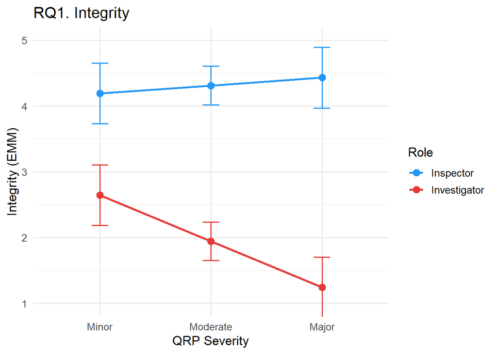

```r
emm_Integrity_df = as.data.frame(
  emmeans(
    T4,
    ~ role_ec * severity_num,
    at = list(severity_num = c(0,1,2))
  )
) %>%
  mutate(
    Role = if_else(
      role_ec == 1,
      "Inspector",
      "Investigator"
    ),
    Severity = factor(
      severity_num,
      levels = c(0,1,2),
      labels = c("Minor", "Moderate", "Major")
    )
  )

ggplot(
  emm_Integrity_df,
  aes(
    x = Severity,
    y = emmean,
    color = Role,
    group = Role
  )
) +
  geom_line(linewidth = 1) +
  geom_point(size = 3) +
  geom_errorbar(
    aes(ymin = lower.CL, ymax = upper.CL),
    width = 0.15
  ) +
  scale_color_manual(
    values = c(
      "Inspector" = "#2196F3",
      "Investigator" = "#E53935"
    )
  ) +
  labs(
    title = "RQ1. Integrity",
    y = "Integrity (EMM)",
    x = "QRP Severity"
  ) +
  theme_minimal(base_size = 13) +
  coord_cartesian(ylim = c(1, 5))
```

##Likeability

**Research Question 2: How is likeability influenced by role and QRP severity?**

**Hypothesis 2a:** Investigators will be rated more likeable than inspectors.

**Hypothesis 2b:** At low QRP severity, investigators will be rated more likeable than inspectors, but at high QRP severity, inspectors will be rated more likeable than investigators.

###Random-effects structure for Likeability

```r
L4_max1 = lmer(
  likeability ~ role_ec * severity_num +
    (1 + role_ec * severity_num | responseid),
  data = tl_dat,
  REML = FALSE,
  control = lmerControl(optimizer = "bobyqa")
)
```

```
## boundary (singular) fit: see help('isSingular')
```

```r
L4_max1_singular = isSingular(L4_max1, tol = 1e-4)
print(L4_max1_singular)
```

```
## [1] TRUE
```

```r
# Step down: remove random interaction slope.
L4_max2 = lmer(
  likeability ~ role_ec * severity_num +
    (1 + role_ec + severity_num | responseid),
  data = tl_dat,
  REML = FALSE,
  control = lmerControl(optimizer = "bobyqa")
)
```

```
## boundary (singular) fit: see help('isSingular')
```

```r
L4_max2_singular = isSingular(L4_max2, tol = 1e-4)
print(L4_max2_singular)
```

```
## [1] TRUE
```

```r
# Step down: retain random role slope only.
L4_max3 = lmer(
  likeability ~ role_ec * severity_num +
    (1 + role_ec | responseid),
  data = tl_dat,
  REML = FALSE,
  control = lmerControl(optimizer = "bobyqa")
)

L4_max3_singular = isSingular(L4_max3, tol = 1e-4)
print(L4_max3_singular)
```

```
## [1] FALSE
```

```r
# Test preregistered vignette random intercept with the maximal
# participant-level structure.
L4_prereg = lmer(
  likeability ~ role_ec * severity_num +
    (1 + role_ec * severity_num | responseid) +
    (1 | vignette_id),
  data = tl_dat,
  REML = FALSE,
  control = lmerControl(optimizer = "bobyqa")
)

L4_prereg_singular = isSingular(L4_prereg, tol = 1e-4)
print(L4_prereg_singular)
```

```
## [1] FALSE
```

```r
likeability_uses_vignette_term = !L4_prereg_singular

cat(
  "Likeability final random-effects structure includes vignette intercept:",
  likeability_uses_vignette_term,
  "\n"
)
```

```
## Likeability final random-effects structure includes vignette intercept: TRUE
```

###step-up models

```r
if (likeability_uses_vignette_term) {

  random_part_likeability = "participant_maximal_plus_vignette"

  M0_like = lmer(
    likeability ~ 1 +
      (1 + role_ec * severity_num | responseid) +
      (1 | vignette_id),
    data = tl_dat,
    REML = FALSE,
    control = lmerControl(optimizer = "bobyqa")
  )

  L1 = lmer(
    likeability ~ role_ec +
      (1 + role_ec * severity_num | responseid) +
      (1 | vignette_id),
    data = tl_dat,
    REML = FALSE,
    control = lmerControl(optimizer = "bobyqa")
  )

  L2 = lmer(
    likeability ~ severity_num +
      (1 + role_ec * severity_num | responseid) +
      (1 | vignette_id),
    data = tl_dat,
    REML = FALSE,
    control = lmerControl(optimizer = "bobyqa")
  )

  L3 = lmer(
    likeability ~ role_ec + severity_num +
      (1 + role_ec * severity_num | responseid) +
      (1 | vignette_id),
    data = tl_dat,
    REML = FALSE,
    control = lmerControl(optimizer = "bobyqa")
  )

  L4 = L4_prereg

} else {

  random_part_likeability = "participant_maximal"

  M0_like = lmer(
    likeability ~ 1 +
      (1 + role_ec * severity_num | responseid),
    data = tl_dat,
    REML = FALSE,
    control = lmerControl(optimizer = "bobyqa")
  )

  L1 = lmer(
    likeability ~ role_ec +
      (1 + role_ec * severity_num | responseid),
    data = tl_dat,
    REML = FALSE,
    control = lmerControl(optimizer = "bobyqa")
  )

  L2 = lmer(
    likeability ~ severity_num +
      (1 + role_ec * severity_num | responseid),
    data = tl_dat,
    REML = FALSE,
    control = lmerControl(optimizer = "bobyqa")
  )

  L3 = lmer(
    likeability ~ role_ec + severity_num +
      (1 + role_ec * severity_num | responseid),
    data = tl_dat,
    REML = FALSE,
    control = lmerControl(optimizer = "bobyqa")
  )

  L4 = L4_max1
}
```

```
## boundary (singular) fit: see help('isSingular')
```

```
## boundary (singular) fit: see help('isSingular')
## boundary (singular) fit: see help('isSingular')
## boundary (singular) fit: see help('isSingular')
```

```r
cat("Likeability final model singularity:\n")
```

```
## Likeability final model singularity:
```

```r
print(isSingular(M0_like))
```

```
## [1] TRUE
```

```r
print(isSingular(L1))
```

```
## [1] TRUE
```

```r
print(isSingular(L2))
```

```
## [1] TRUE
```

```r
print(isSingular(L3))
```

```
## [1] TRUE
```

```r
print(isSingular(L4))
```

```
## [1] FALSE
```

```r
likeability_models = list(
  M0_like,
  L1,
  L2,
  L3,
  L4
)

likeability_model_names = c(
  "Model 0: Null",
  "Model 2a: Role",
  "Model 2b: QRP Severity",
  "Model 2c: Role + QRP Severity",
  "Model 2d: Role × QRP Severity"
)

likeability_fit = model_fit_table(
  likeability_models,
  likeability_model_names
)

print(likeability_fit)
```

```
##                           Model    AIC    BIC  logLik Chisq df      p
## 1                 Model 0: Null 6145.0 6221.5 -3059.5     —  —      —
## 2                Model 2a: Role 6136.8 6219.2 -3054.4 10.17  1  0.001
## 3        Model 2b: QRP Severity 6146.8 6229.2 -3059.4  0.00  0      —
## 4 Model 2c: Role + QRP Severity 6137.6 6225.9 -3053.8 11.18  1 < .001
## 5 Model 2d: Role × QRP Severity 6122.9 6217.0 -3045.4 16.75  1 < .001
```

```r
summary(L1)
```

```
## Linear mixed model fit by maximum likelihood . t-tests use Satterthwaite's
##   method [lmerModLmerTest]
## Formula: likeability ~ role_ec + (1 + role_ec * severity_num | responseid) +
##     (1 | vignette_id)
##    Data: tl_dat
## Control: lmerControl(optimizer = "bobyqa")
##
##       AIC       BIC    logLik -2*log(L)  df.resid
##    6136.8    6219.2   -3054.4    6108.8      2645
##
## Scaled residuals:
##     Min      1Q  Median      3Q     Max
## -4.9236 -0.4846  0.0137  0.5093  4.1438
##
## Random effects:
##  Groups      Name                 Variance Std.Dev. Corr
##  responseid  (Intercept)          0.102882 0.32075
##              role_ec              0.244468 0.49444   0.43
##              severity_num         0.005495 0.07413  -0.72 -0.80
##              role_ec:severity_num 0.047381 0.21767   0.07 -0.23 -0.31
##  vignette_id (Intercept)          0.099482 0.31541
##  Residual                         0.361388 0.60116
## Number of obs: 2659, groups:  responseid, 444; vignette_id, 6
##
## Fixed effects:
##             Estimate Std. Error     df t value Pr(>|t|)
## (Intercept)   3.1326     0.1299 6.0741  24.109 2.91e-07 ***
## role_ec       0.6700     0.1314 6.3508   5.099  0.00188 **
## ---
## Signif. codes:  0 '***' 0.001 '**' 0.01 '*' 0.05 '.' 0.1 ' ' 1
##
## Correlation of Fixed Effects:
##         (Intr)
## role_ec 0.005
## optimizer (bobyqa) convergence code: 0 (OK)
## boundary (singular) fit: see help('isSingular')
```

```r
summary(L2)
```

```
## Linear mixed model fit by maximum likelihood . t-tests use Satterthwaite's
##   method [lmerModLmerTest]
## Formula:
## likeability ~ severity_num + (1 + role_ec * severity_num | responseid) +
##     (1 | vignette_id)
##    Data: tl_dat
## Control: lmerControl(optimizer = "bobyqa")
##
##       AIC       BIC    logLik -2*log(L)  df.resid
##    6146.8    6229.2   -3059.4    6118.8      2645
##
## Scaled residuals:
##     Min      1Q  Median      3Q     Max
## -4.9229 -0.4850  0.0173  0.5123  4.1476
##
## Random effects:
##  Groups      Name                 Variance Std.Dev. Corr
##  responseid  (Intercept)          0.102888 0.32076
##              role_ec              0.244488 0.49446   0.43
##              severity_num         0.005495 0.07413  -0.72 -0.80
##              role_ec:severity_num 0.047366 0.21764   0.07 -0.23 -0.31
##  vignette_id (Intercept)          0.526275 0.72545
##  Residual                         0.361393 0.60116
## Number of obs: 2659, groups:  responseid, 444; vignette_id, 6
##
## Fixed effects:
##              Estimate Std. Error      df t value Pr(>|t|)
## (Intercept)    3.2977     0.4689  5.9442   7.033  0.00043 ***
## severity_num  -0.1656     0.3630  5.9328  -0.456  0.66444
## ---
## Signif. codes:  0 '***' 0.001 '**' 0.01 '*' 0.05 '.' 0.1 ' ' 1
##
## Correlation of Fixed Effects:
##             (Intr)
## severity_nm -0.774
## optimizer (bobyqa) convergence code: 0 (OK)
## boundary (singular) fit: see help('isSingular')
```

```r
summary(L3)
```

```
## Linear mixed model fit by maximum likelihood . t-tests use Satterthwaite's
##   method [lmerModLmerTest]
## Formula: likeability ~ role_ec + severity_num + (1 + role_ec * severity_num |
##     responseid) + (1 | vignette_id)
##    Data: tl_dat
## Control: lmerControl(optimizer = "bobyqa")
##
##       AIC       BIC    logLik -2*log(L)  df.resid
##    6137.6    6225.9   -3053.8    6107.6      2644
##
## Scaled residuals:
##     Min      1Q  Median      3Q     Max
## -4.9203 -0.4842  0.0102  0.5100  4.1453
##
## Random effects:
##  Groups      Name                 Variance Std.Dev. Corr
##  responseid  (Intercept)          0.102879 0.32075
##              role_ec              0.244474 0.49444   0.43
##              severity_num         0.005494 0.07412  -0.72 -0.80
##              role_ec:severity_num 0.047388 0.21769   0.07 -0.23 -0.31
##  vignette_id (Intercept)          0.080991 0.28459
##  Residual                         0.361386 0.60115
## Number of obs: 2659, groups:  responseid, 444; vignette_id, 6
##
## Fixed effects:
##              Estimate Std. Error      df t value Pr(>|t|)
## (Intercept)    3.2988     0.1853  6.0207  17.807 1.95e-06 ***
## role_ec        0.6703     0.1191  6.4261   5.629  0.00106 **
## severity_num  -0.1661     0.1431  5.9467  -1.161  0.29019
## ---
## Signif. codes:  0 '***' 0.001 '**' 0.01 '*' 0.05 '.' 0.1 ' ' 1
##
## Correlation of Fixed Effects:
##             (Intr) role_c
## role_ec      0.007
## severity_nm -0.773 -0.005
## optimizer (bobyqa) convergence code: 0 (OK)
## boundary (singular) fit: see help('isSingular')
```

```r
summary(L4)
```

```
## Linear mixed model fit by maximum likelihood . t-tests use Satterthwaite's
##   method [lmerModLmerTest]
## Formula: likeability ~ role_ec * severity_num + (1 + role_ec * severity_num |
##     responseid) + (1 | vignette_id)
##    Data: tl_dat
## Control: lmerControl(optimizer = "bobyqa")
##
##       AIC       BIC    logLik -2*log(L)  df.resid
##    6122.9    6217.0   -3045.4    6090.9      2643
##
## Scaled residuals:
##     Min      1Q  Median      3Q     Max
## -4.9347 -0.4889  0.0107  0.5206  4.1662
##
## Random effects:
##  Groups      Name                 Variance Std.Dev. Corr
##  responseid  (Intercept)          0.102734 0.32052
##              role_ec              0.244096 0.49406   0.43
##              severity_num         0.005486 0.07407  -0.72 -0.80
##              role_ec:severity_num 0.047269 0.21741   0.07 -0.23 -0.31
##  vignette_id (Intercept)          0.004113 0.06414
##  Residual                         0.361494 0.60124
## Number of obs: 2659, groups:  responseid, 444; vignette_id, 6
##
## Fixed effects:
##                      Estimate Std. Error       df t value Pr(>|t|)
## (Intercept)           3.29898    0.04781  7.17900  68.996 2.13e-11 ***
## role_ec               0.33042    0.05104  9.30302   6.474 9.90e-05 ***
## severity_num         -0.16624    0.03528  5.91977  -4.711  0.00341 **
## role_ec:severity_num  0.34080    0.03660  6.84249   9.313 3.93e-05 ***
## ---
## Signif. codes:  0 '***' 0.001 '**' 0.01 '*' 0.05 '.' 0.1 ' ' 1
##
## Correlation of Fixed Effects:
##             (Intr) role_c svrty_
## role_ec      0.063
## severity_nm -0.754 -0.037
## rl_c:svrty_  0.006 -0.689 -0.009
```

###fixed effects and planned role contrasts

```r
likeability_fixed_effects = lapply(
  likeability_models,
  get_fixed_effects
)

names(likeability_fixed_effects) = paste0("Model_", 0:4)

print(likeability_fixed_effects)
```

```
## $Model_0
##     Parameter        b        SE       df        t            p
## 1 (Intercept) 3.132077 0.3017862 5.955137 10.37846 4.915248e-05
##
## $Model_1
##     Parameter        b        SE       df         t            p
## 1 (Intercept) 3.132578 0.1299363 6.074073 24.108559 2.913640e-07
## 2     role_ec 0.669988 0.1313935 6.350772  5.099096 1.877973e-03
##
## $Model_2
##      Parameter          b        SE       df          t            p
## 1  (Intercept)  3.2977155 0.4688852 5.944172  7.0330982 0.0004300994
## 2 severity_num -0.1656288 0.3630222 5.932758 -0.4562498 0.6644353212
##
## $Model_3
##      Parameter          b        SE       df         t            p
## 1  (Intercept)  3.2988129 0.1852537 6.020665 17.806999 1.950905e-06
## 2      role_ec  0.6703416 0.1190908 6.426069  5.628827 1.064798e-03
## 3 severity_num -0.1660577 0.1430538 5.946674 -1.160806 2.901895e-01
##
## $Model_4
##              Parameter          b         SE       df         t            p
## 1          (Intercept)  3.2989830 0.04781424 7.179002 68.995829 2.131419e-11
## 2              role_ec  0.3304157 0.05103971 9.303015  6.473698 9.901884e-05
## 3         severity_num -0.1662369 0.03528356 5.919768 -4.711454 3.405761e-03
## 4 role_ec:severity_num  0.3408044 0.03659558 6.842494  9.312721 3.934978e-05
```

```r
# Planned role comparisons at each severity.
emm_like_role = emmeans(
  L4,
  pairwise ~ role_ec | severity_num,
  at = list(severity_num = c(0,1,2)),
  adjust = "bonferroni"
)
summary(emm_like_role$contrasts)
```

```
## severity_num = 0:
##  contrast               estimate    SE   df t.ratio p.value
##  (role_ec-1) - role_ec1   -0.661 0.156 13.3  -4.247  0.0009
##
## severity_num = 1:
##  contrast               estimate    SE   df t.ratio p.value
##  (role_ec-1) - role_ec1   -1.342 0.105 12.6 -12.802 <0.0001
##
## severity_num = 2:
##  contrast               estimate    SE   df t.ratio p.value
##  (role_ec-1) - role_ec1   -2.024 0.158 13.1 -12.791 <0.0001
##
## Degrees-of-freedom method: kenward-roger
```

```r
# Cohen's d for each role comparison.
eff_size(
  emmeans(
    L4,
    ~ role_ec | severity_num,
    at = list(severity_num = c(0,1,2))
  ),
  sigma = sigma(L4),
  edf = df.residual(L4)
)
```

```
## severity_num = 0:
##  contrast               effect.size    SE   df lower.CL upper.CL
##  (role_ec-1) - role_ec1       -1.10 0.259 13.3    -1.66    -0.54
##
## severity_num = 1:
##  contrast               effect.size    SE   df lower.CL upper.CL
##  (role_ec-1) - role_ec1       -2.23 0.177 12.8    -2.62    -1.85
##
## severity_num = 2:
##  contrast               effect.size    SE   df lower.CL upper.CL
##  (role_ec-1) - role_ec1       -3.37 0.267 13.4    -3.94    -2.79
##
## sigma used for effect sizes: 0.6012
## Degrees-of-freedom method: inherited from kenward-roger when re-gridding
## Confidence level used: 0.95
```

###figure

```r
emm_like_df = as.data.frame(
  emmeans(
    L4,
    ~ role_ec * severity_num,
    at = list(severity_num = c(0,1,2))
  )
) %>%
  mutate(
    Role = if_else(
      role_ec == 1,
      "Inspector",
      "Investigator"
    ),
    Severity = factor(
      severity_num,
      levels = c(0,1,2),
      labels = c("Minor", "Moderate", "Major")
    )
  )
```

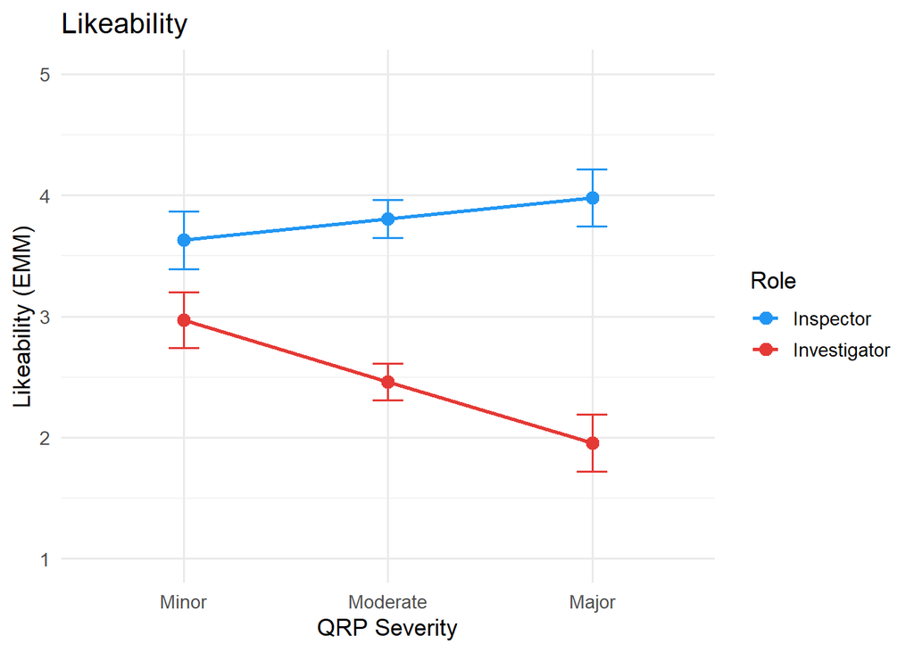

```r
ggplot(
  emm_like_df,
  aes(
    x = Severity,
    y = emmean,
    color = Role,
    group = Role
  )
) +
  geom_line(linewidth = 1) +
  geom_point(size = 3) +
  geom_errorbar(
    aes(ymin = lower.CL, ymax = upper.CL),
    width = 0.15
  ) +
  scale_color_manual(
    values = c(
      "Inspector" = "#2196F3",
      "Investigator" = "#E53935"
    )
  ) +
  labs(
    title = "Likeability",
    y = "Likeability (EMM)",
    x = "QRP Severity"
  ) +
  theme_minimal(base_size = 13) +
  coord_cartesian(ylim = c(1, 5))
```

##TRUENESS

Research Question 3: Is the perceived trueness of the finding influenced by QRP severity?**

**Hypothesis 3:** Perceived trueness will decrease as QRP severity increases.

###data and model

```r
# Trueness is only rated for investigators, with one item per vignette.
trueness_dat = filtered_by_age %>%
  transmute(
    responseid,
    minor = parse_num(kcon),
    moderate = parse_num(hcon),
    major = parse_num(xcon)
  ) %>%
  pivot_longer(
    cols = c(minor, moderate, major),
    names_to = "severity",
    values_to = "trueness"
  ) %>%
  mutate(
    severity = factor(
      severity,
      levels = c("minor", "moderate", "major")
    ),
    severity_num = case_when(
      severity == "minor" ~ 0,
      severity == "moderate" ~ 1,
      severity == "major" ~ 2
    ),
    responseid = factor(responseid),
    trueness_c = trueness - 3
  )


# Descriptives.
trueness_descriptives = trueness_dat %>%
  group_by(severity) %>%
  summarise(
    n = sum(!is.na(trueness)),
    M = round(mean(trueness, na.rm = TRUE), 2),
    SD = round(sd(trueness, na.rm = TRUE), 2),
    .groups = "drop"
  )

print(trueness_descriptives)
```

```
## # A tibble: 3 × 4
##   severity     n     M    SD
##   <fct>    <int> <dbl> <dbl>
## 1 minor      442  2.97  0.91
## 2 moderate   444  1.85  0.92
## 3 major      444  1.52  0.87
```

```r
range(trueness_dat$trueness, na.rm = TRUE)
```

```
## [1] 1 5
```

```r
mean(trueness_dat$trueness, na.rm = TRUE)
```

```
## [1] 2.113534
```

```r
# FT1: perceived trueness predicted by QRP severity.
FT1 = lmer(
  trueness_c ~ severity_num +
    (1 | responseid) +
    (1 | severity),
  data = trueness_dat,
  REML = FALSE,
  control = lmerControl(optimizer = "bobyqa")
)

summary(FT1)
```

```
## Linear mixed model fit by maximum likelihood . t-tests use Satterthwaite's
##   method [lmerModLmerTest]
## Formula: trueness_c ~ severity_num + (1 | responseid) + (1 | severity)
##    Data: trueness_dat
## Control: lmerControl(optimizer = "bobyqa")
##
##       AIC       BIC    logLik -2*log(L)  df.resid
##    3469.0    3495.0   -1729.5    3459.0      1325
##
## Scaled residuals:
##     Min      1Q  Median      3Q     Max
## -2.7114 -0.6641 -0.0688  0.4275  4.0200
##
## Random effects:
##  Groups     Name        Variance Std.Dev.
##  responseid (Intercept) 0.15549  0.3943
##  severity   (Intercept) 0.03355  0.1832
##  Residual               0.65498  0.8093
## Number of obs: 1330, groups:  responseid, 444; severity, 3
##
## Fixed effects:
##              Estimate Std. Error      df t value Pr(>|t|)
## (Intercept)   -0.1614     0.1719  3.0724  -0.939    0.416
## severity_num  -0.7239     0.1323  2.9996  -5.470    0.012 *
## ---
## Signif. codes:  0 '***' 0.001 '**' 0.01 '*' 0.05 '.' 0.1 ' ' 1
##
## Correlation of Fixed Effects:
##             (Intr)
## severity_nm -0.770
```

```r
isSingular(FT1)
```

```
## [1] FALSE
```

```r
# Fixed effects, including Satterthwaite df, t, and p.
trueness_fixed_effects = get_fixed_effects(FT1)
print(trueness_fixed_effects)
```

```
##      Parameter          b        SE       df          t          p
## 1  (Intercept) -0.1613977 0.1718789 3.072385 -0.9390195 0.41551002
## 2 severity_num -0.7238821 0.1323405 2.999581 -5.4698471 0.01201624
```

```r
# Planned comparisons across severity levels.
emm_trueness = emmeans(
  FT1,
  pairwise ~ severity_num,
  at = list(severity_num = c(0,1,2)),
  adjust = "bonferroni"
)

summary(emm_trueness$contrasts)
```

```
##  contrast                      estimate    SE   df t.ratio p.value
##  severity_num0 - severity_num1    0.724 0.228 8.83   3.174  0.0347
##  severity_num0 - severity_num2    1.448 0.456 8.83   3.174  0.0347
##  severity_num1 - severity_num2    0.724 0.228 8.83   3.174  0.0347
##
## Degrees-of-freedom method: kenward-roger
## P value adjustment: bonferroni method for 3 tests
```

```r
eff_size(
  emmeans(
    FT1,
    ~ severity_num,
    at = list(severity_num = c(0,1,2))
  ),
  sigma = sigma(FT1),
  edf = df.residual(FT1)
)
```

```
##  contrast                      effect.size    SE   df lower.CL upper.CL
##  severity_num0 - severity_num1       0.894 0.282 8.66    0.252     1.54
##  severity_num0 - severity_num2       1.789 0.565 8.76    0.506     3.07
##  severity_num1 - severity_num2       0.894 0.282 8.66    0.252     1.54
##
## sigma used for effect sizes: 0.8093
## Degrees-of-freedom method: inherited from kenward-roger when re-gridding
## Confidence level used: 0.95
```

###figure

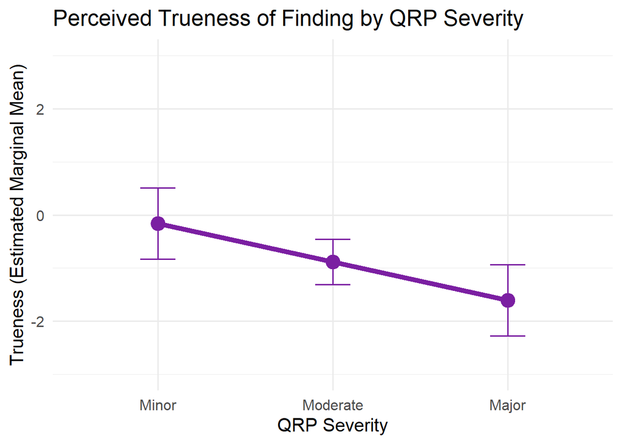

```r
emm_true_df = as.data.frame(
  emmeans(
    FT1,
    ~ severity_num,
    at = list(severity_num = c(0,1,2))
  )
) %>%
  mutate(
    Severity = factor(
      severity_num,
      levels = c(0,1,2),
      labels = c("Minor", "Moderate", "Major")
    )
  )

ggplot(
  emm_true_df,
  aes(
    x = Severity,
    y = emmean,
    group = 1
  )
) +
  geom_line(linewidth = 2, color = "#7B1FA2") +
  geom_point(size = 5, color = "#7B1FA2") +
  geom_errorbar(
    aes(ymin = lower.CL, ymax = upper.CL),
    width = 0.20,
    color = "#7B1FA2"
  ) +
  labs(
    title = "Perceived Trueness of Finding by QRP Severity",
    y = "Trueness (Estimated Marginal Mean)",
    x = "QRP Severity"
  ) +
  theme_minimal(base_size = 15) +
  coord_cartesian(ylim = c(-3, 3))
```

##Robustness checks — demographic covariates

```r
demo_dat = filtered_by_age %>%
  transmute(
    responseid = responseid,
    gender = factor(`gender.identity`),
    political = factor(
      political,
      levels = c(
        "Strongly Liberal",
        "Liberal",
        "Lean Liberal",
        "Centrist",
        "Lean Conservative",
        "Conservative",
        "Strongly Conservative"
      )
    ),
    religion = factor(religion)
  )

tl_robust = tl_dat %>%
  mutate(responseid = as.character(responseid)) %>%
  left_join(demo_dat, by = "responseid") %>%
  mutate(responseid = factor(responseid))


# Integrity robustness model uses the exact random-effects structure

if (Integrity_uses_vignette_term) {

  T4_robust = lmer(
    Integrity ~ role_ec * severity_num +
      gender + political + religion +
      (1 + role_ec | responseid) +
      (1 | vignette_id),
    data = tl_robust,
    REML = FALSE,
    control = lmerControl(optimizer = "bobyqa")
  )

} else {

  T4_robust = lmer(
    Integrity ~ role_ec * severity_num +
      gender + political + religion +
      (1 + role_ec | responseid),
    data = tl_robust,
    REML = FALSE,
    control = lmerControl(optimizer = "bobyqa")
  )
}


# Likeability robustness model uses the exact random-effects structure

if (likeability_uses_vignette_term) {

  L4_robust = lmer(
    likeability ~ role_ec * severity_num +
      gender + political + religion +
      (1 + role_ec * severity_num | responseid) +
      (1 | vignette_id),
    data = tl_robust,
    REML = FALSE,
    control = lmerControl(optimizer = "bobyqa")
  )

} else {

  L4_robust = lmer(
    likeability ~ role_ec * severity_num +
      gender + political + religion +
      (1 + role_ec * severity_num | responseid),
    data = tl_robust,
    REML = FALSE,
    control = lmerControl(optimizer = "bobyqa")
  )
}
```

```
## boundary (singular) fit: see help('isSingular')
```

```r
summary(T4_robust)
```

```
## Linear mixed model fit by maximum likelihood . t-tests use Satterthwaite's
##   method [lmerModLmerTest]
## Formula: Integrity ~ role_ec * severity_num + gender + political + religion +
##     (1 + role_ec | responseid) + (1 | vignette_id)
##    Data: tl_robust
## Control: lmerControl(optimizer = "bobyqa")
##
##       AIC       BIC    logLik -2*log(L)  df.resid
##    5530.1    5664.6   -2742.0    5484.1      2533
##
## Scaled residuals:
##     Min      1Q  Median      3Q     Max
## -4.9073 -0.5243  0.0032  0.4953  5.4977
##
## Random effects:
##  Groups      Name        Variance Std.Dev. Corr
##  responseid  (Intercept) 0.03686  0.1920
##              role_ec     0.15995  0.3999   0.40
##  vignette_id (Intercept) 0.01845  0.1358
##  Residual                0.37512  0.6125
## Number of obs: 2556, groups:  responseid, 426; vignette_id, 6
##
## Fixed effects:
##                                     Estimate Std. Error         df t value
## (Intercept)                         3.430502   0.122425  20.509564  28.021
## role_ec                             0.767019   0.091810   6.558374   8.354
## severity_num                       -0.294797   0.069513   5.987705  -4.241
## genderNon-binary / third gender    -0.274706   0.226144 425.129810  -1.215
## genderPrefer not to say            -0.019047   0.226506 425.129810  -0.084
## genderWoman                        -0.006810   0.039797 425.129807  -0.171
## politicalLiberal                   -0.044094   0.081268 425.129799  -0.543
## politicalLean Liberal              -0.093477   0.086573 425.129801  -1.080
## politicalCentrist                  -0.064743   0.077974 425.129796  -0.830
## politicalLean Conservative         -0.065080   0.080735 425.129797  -0.806
## politicalConservative              -0.017470   0.077247 425.129797  -0.226
## politicalStrongly Conservative     -0.043523   0.085752 425.129799  -0.508
## religionIslam                       0.320622   0.312840 425.129810   1.025
## religionJudaism                     0.054216   0.221484 425.129810   0.245
## religionNot Affiliated             -0.002842   0.056131 425.129808  -0.051
## religionOther                       0.143886   0.070596 425.129810   2.038
```

[output cut: 8 more lines]

```
## genderWoman                       0.864216
## politicalLiberal                  0.587710
## politicalLean Liberal             0.280867
## politicalCentrist                 0.406826
## politicalLean Conservative        0.420641
## politicalConservative             0.821191
## politicalStrongly Conservative    0.612040
## religionIslam                     0.306005
## religionJudaism                   0.806741
## religionNot Affiliated            0.959639
## religionOther                     0.042151 *
## religionProtestantism (Christian) 0.088098 .
## role_ec:severity_num              0.000946 ***
## ---
## Signif. codes:  0 '***' 0.001 '**' 0.01 '*' 0.05 '.' 0.1 ' ' 1
```

```
##
## Correlation matrix not shown by default, as p = 18 > 12.
## Use print(x, correlation=TRUE)  or
##     vcov(x)        if you need it
```

```r
summary(L4_robust)
```

```
## Linear mixed model fit by maximum likelihood . t-tests use Satterthwaite's
##   method [lmerModLmerTest]
## Formula:
## likeability ~ role_ec * severity_num + gender + political + religion +
##     (1 + role_ec * severity_num | responseid) + (1 | vignette_id)
##    Data: tl_robust
## Control: lmerControl(optimizer = "bobyqa")
##
##       AIC       BIC    logLik -2*log(L)  df.resid
##    5896.9    6072.2   -2918.4    5836.9      2526
##
## Scaled residuals:
##     Min      1Q  Median      3Q     Max
## -4.7898 -0.4793  0.0199  0.5288  3.7048
##
## Random effects:
##  Groups      Name                 Variance Std.Dev. Corr
##  responseid  (Intercept)          0.095861 0.30961
##              role_ec              0.237700 0.48754   0.45
##              severity_num         0.005643 0.07512  -0.71 -0.87
##              role_ec:severity_num 0.045236 0.21269   0.05 -0.20 -0.21
##  vignette_id (Intercept)          0.003822 0.06182
##  Residual                         0.363455 0.60287
## Number of obs: 2556, groups:  responseid, 426; vignette_id, 6
##
## Fixed effects:
##                                    Estimate Std. Error        df t value
## (Intercept)                         3.19401    0.10534 143.19947  30.320
## role_ec                             0.32277    0.05006   9.53166   6.448
## severity_num                       -0.16843    0.03438   5.91270  -4.899
## genderNon-binary / third gender    -0.02944    0.25817 426.02942  -0.114
## genderPrefer not to say             0.30667    0.25858 426.02942   1.186
## genderWoman                         0.04479    0.04543 426.02942   0.986
## politicalLiberal                    0.05273    0.09278 426.02941   0.568
## politicalLean Liberal              -0.02197    0.09883 426.02941  -0.222
## politicalCentrist                  -0.02665    0.08902 426.02941  -0.299
## politicalLean Conservative         -0.01680    0.09217 426.02941  -0.182
## politicalConservative               0.02526    0.08819 426.02941   0.286
## politicalStrongly Conservative      0.02418    0.09790 426.02941   0.247
## religionIslam                       0.53101    0.35714 426.02942   1.487
```

[output cut: 11 more lines]

```
## genderWoman                        0.32470
## politicalLiberal                   0.57010
## politicalLean Liberal              0.82420
## politicalCentrist                  0.76482
## politicalLean Conservative         0.85548
## politicalConservative              0.77465
## politicalStrongly Conservative     0.80506
## religionIslam                      0.13779
## religionJudaism                    0.54156
## religionNot Affiliated             0.62896
## religionOther                      0.02597 *
## religionProtestantism (Christian)  0.04574 *
## role_ec:severity_num              2.87e-05 ***
## ---
## Signif. codes:  0 '***' 0.001 '**' 0.01 '*' 0.05 '.' 0.1 ' ' 1
```

```
##
## Correlation matrix not shown by default, as p = 18 > 12.
## Use print(x, correlation=TRUE)  or
##     vcov(x)        if you need it
```

```
## optimizer (bobyqa) convergence code: 0 (OK)
## boundary (singular) fit: see help('isSingular')
```

```r
# Compare interaction coefficients with and without demographic covariates.
cat("Integrity interaction, original:",
    fixef(T4)[["role_ec:severity_num"]], "\n")
```

```
## Integrity interaction, original: 0.4111207
```

```r
cat("Integrity interaction, adjusted:",
    fixef(T4_robust)[["role_ec:severity_num"]], "\n")
```

```
## Integrity interaction, adjusted: 0.4192097
```

```r
cat("Likeability interaction, original:",
    fixef(L4)[["role_ec:severity_num"]], "\n")
```

```
## Likeability interaction, original: 0.3408044
```

```r
cat("Likeability interaction, adjusted:",
    fixef(L4_robust)[["role_ec:severity_num"]], "\n")
```

```
## Likeability interaction, adjusted: 0.3480047
```

# APA TABLES

```r
#APA Model Comparison Tables

# Helper: extract fixed effects from a model into a clean data frame
fe_table = function(model) {
  cf = summary(model)$coefficients
  ci = confint(model, method = "Wald")
  ci = ci[rownames(cf), ]

  data.frame(
    Parameter = rownames(cf),
    b         = round(cf[, "Estimate"], 2),
    SE        = round(cf[, "Std. Error"], 2),
    df        = round(cf[, "df"], 2),
    CI_low    = round(ci[, 1], 2),
    CI_high   = round(ci[, 2], 2),
    t         = round(cf[, "t value"], 2),
    p         = ifelse(
      cf[, "Pr(>|t|)"] < .001,
      "< .001",
      formatC(cf[, "Pr(>|t|)"], digits = 3, format = "f")
    )
  )
}


relabel = function(df) {
  df$Parameter = dplyr::recode(
    df$Parameter,
    "(Intercept)"          = "Intercept",
    "role_ec"              = "Role",
    "severity_num"         = "QRP Severity",
    "role_ec:severity_num" = "Role × QRP Severity"
  )
  df
}


fit_table = function(model_list, model_names) {

  do.call(
    rbind,
    lapply(seq_along(model_list), function(i) {

      m = model_list[[i]]

      if (i == 1) {

        chisq_out = NA_character_
        df_out    = NA_character_
        p_out     = NA_character_

      } else {

        lr = anova(
          model_list[[i - 1]],
          m
        )

        chisq_out = formatC(
          lr$Chisq[2],
          digits = 2,
          format = "f"
        )

        df_out = as.character(
          lr$Df[2]
        )

        p_out = ifelse(
          lr$`Pr(>Chisq)`[2] < .001,
          "< .001",
          formatC(
            lr$`Pr(>Chisq)`[2],
            digits = 3,
            format = "f"
          )
        )
      }

      data.frame(
        Model  = model_names[i],
        AIC    = round(AIC(m), 1),
        BIC    = round(BIC(m), 1),
        logLik = round(as.numeric(logLik(m)), 1),
        Chisq  = chisq_out,
        df     = df_out,
        p      = p_out
      )
    })
  )
}


#TABLE 1: Integrity model fit

fit_table(
  list(
    T1,
    T2,
    T3,
    T4
  ),
  c(
    "M1a: Role",
    "M1b: Severity",
    "M1c: Role + Severity",
    "M1d: Role × Severity"
  )
) %>%

  kable(
    caption = "Table 1. Model Fit Indices for Step-Up Integrity Models",
    col.names = c(
      "Model",
      "AIC",
      "BIC",
      "logLik",
      "$\\chi^2$",
      "df",
      "p"
    ),
    align = "lrrrrrr",
    escape = FALSE
  ) %>%

  kable_styling(
    full_width = FALSE,
    bootstrap_options = "condensed"
  ) %>%

  footnote(
    general =
      "Lower AIC/BIC indicates better model fit. Chi-square tests reflect likelihood ratio comparison to the preceding model."
  )
```

Table 1. Model Fit Indices for Step-Up Integrity Models

| Model | AIC | BIC | logLik | $\chi^2$ | df | p |
| --- | --- | --- | --- | --- | --- | --- |
| M1a: Role | 5744.0 | 5785.2 | -2865.0 | NA | NA | NA |
| M1b: Severity | 5756.6 | 5797.8 | -2871.3 | 0.00 | 0 | NA |
| M1c: Role + Severity | 5743.9 | 5791.0 | -2863.9 | 14.70 | 1 | < .001 |
| M1d: Role × Severity | 5734.4 | 5787.3 | -2858.2 | 11.52 | 1 | < .001 |

Note:  
Lower AIC/BIC indicates better model fit. Chi-square tests reflect likelihood ratio comparison to the preceding model.

```r
#TABLE 2: Integrity fixed effects (Model 4)

fe_table(T4) %>%

  relabel() %>%

  mutate(
    `95% CI` =
      paste0(
        "[",
        CI_low,
        ", ",
        CI_high,
        "]"
      )
  ) %>%

  select(
    Parameter,
    b,
    SE,
    df,
    `95% CI`,
    t,
    p
  ) %>%

  kable(
    caption =
      "Table 2. Fixed Effects for Integrity Model 4 (Role × QRP Severity)",

    col.names = c(
      "Parameter",
      "b",
      "SE",
      "df",
      "95% CI",
      "t",
      "p"
    ),

    align = "lrrrrrr"
  ) %>%

  kable_styling(
    full_width = FALSE,
    bootstrap_options = "condensed"
  ) %>%

  footnote(
    general =
      "Role: inspector = 1, investigator = −1. QRP Severity: minor = 0, moderate = 1, major = 2."
  )
```

Table 2. Fixed Effects for Integrity Model 4 (Role × QRP Severity)

|  | Parameter | b | SE | df | 95% CI | t | p |
| --- | --- | --- | --- | --- | --- | --- | --- |
| (Intercept) | Intercept | 3.42 | 0.09 | 6.12 | [3.24, 3.6] | 37.89 | < .001 |
| role_ec | Role | 0.77 | 0.09 | 6.54 | [0.59, 0.95] | 8.42 | < .001 |
| severity_num | QRP Severity | -0.29 | 0.07 | 5.99 | [-0.43, -0.16] | -4.19 | 0.006 |
| role_ec:severity_num | Role × QRP Severity | 0.41 | 0.07 | 5.99 | [0.27, 0.55] | 5.91 | 0.001 |

Note:  
Role: inspector = 1, investigator = −1. QRP Severity: minor = 0, moderate = 1, major = 2.

```r
# TABLE 3: Likeability model fit

fit_table(
  list(
    L1,
    L2,
    L3,
    L4
  ),
  c(
    "M2a: Role",
    "M2b: Severity",
    "M2c: Role + Severity",
    "M2d: Role × Severity"
  )
) %>%

  kable(
    caption =
      "Table 3. Model Fit Indices for Step-Up Likeability Models",

    col.names = c(
      "Model",
      "AIC",
      "BIC",
      "logLik",
      "$\\chi^2$",
      "df",
      "p"
    ),

    align = "lrrrrrr",
    escape = FALSE
  ) %>%

  kable_styling(
    full_width = FALSE,
    bootstrap_options = "condensed"
  ) %>%

  footnote(
    general =
      "Lower AIC/BIC indicates better model fit. Chi-square tests reflect likelihood ratio comparison to the preceding model."
  )
```

Table 3. Model Fit Indices for Step-Up Likeability Models

| Model | AIC | BIC | logLik | $\chi^2$ | df | p |
| --- | --- | --- | --- | --- | --- | --- |
| M2a: Role | 6136.8 | 6219.2 | -3054.4 | NA | NA | NA |
| M2b: Severity | 6146.8 | 6229.2 | -3059.4 | 0.00 | 0 | NA |
| M2c: Role + Severity | 6137.6 | 6225.9 | -3053.8 | 11.18 | 1 | < .001 |
| M2d: Role × Severity | 6122.9 | 6217.0 | -3045.4 | 16.75 | 1 | < .001 |

Note:  
Lower AIC/BIC indicates better model fit. Chi-square tests reflect likelihood ratio comparison to the preceding model.

```r
#TABLE 4: Likeability fixed effects (Model 4)

fe_table(L4) %>%

  relabel() %>%

  mutate(
    `95% CI` =
      paste0(
        "[",
        CI_low,
        ", ",
        CI_high,
        "]"
      )
  ) %>%

  select(
    Parameter,
    b,
    SE,
    df,
    `95% CI`,
    t,
    p
  ) %>%

  kable(
    caption =
      "Table 4. Fixed Effects for Likeability Model 4 (Role × QRP Severity)",

    col.names = c(
      "Parameter",
      "b",
      "SE",
      "df",
      "95% CI",
      "t",
      "p"
    ),

    align = "lrrrrrr"
  ) %>%

  kable_styling(
    full_width = FALSE,
    bootstrap_options = "condensed"
  ) %>%

  footnote(
    general =
      "Role: inspector = 1, investigator = −1. QRP Severity: minor = 0, moderate = 1, major = 2."
  )
```

Table 4. Fixed Effects for Likeability Model 4 (Role × QRP Severity)

|  | Parameter | b | SE | df | 95% CI | t | p |
| --- | --- | --- | --- | --- | --- | --- | --- |
| (Intercept) | Intercept | 3.30 | 0.05 | 7.18 | [3.21, 3.39] | 69.00 | < .001 |
| role_ec | Role | 0.33 | 0.05 | 9.30 | [0.23, 0.43] | 6.47 | < .001 |
| severity_num | QRP Severity | -0.17 | 0.04 | 5.92 | [-0.24, -0.1] | -4.71 | 0.003 |
| role_ec:severity_num | Role × QRP Severity | 0.34 | 0.04 | 6.84 | [0.27, 0.41] | 9.31 | < .001 |

Note:  
Role: inspector = 1, investigator = −1. QRP Severity: minor = 0, moderate = 1, major = 2.

```r
#TABLE 5: Trueness fixed effects (FT1)

fe_table(FT1) %>%

  relabel() %>%

  mutate(
    `95% CI` =
      paste0(
        "[",
        CI_low,
        ", ",
        CI_high,
        "]"
      )
  ) %>%

  select(
    Parameter,
    b,
    SE,
    df,
    `95% CI`,
    t,
    p
  ) %>%

  kable(
    caption =
      "Table 5. Fixed Effects for Trueness Model FT1",

    col.names = c(
      "Parameter",
      "b",
      "SE",
      "df",
      "95% CI",
      "t",
      "p"
    ),

    align = "lrrrrrr"
  ) %>%

  kable_styling(
    full_width = FALSE,
    bootstrap_options = "condensed"
  ) %>%

  footnote(
    general =
      "Trueness centered at 3 (neutral midpoint). QRP Severity: minor = 0, moderate = 1, major = 2."
  )
```

Table 5. Fixed Effects for Trueness Model FT1

|  | Parameter | b | SE | df | 95% CI | t | p |
| --- | --- | --- | --- | --- | --- | --- | --- |
| (Intercept) | Intercept | -0.16 | 0.17 | 3.07 | [-0.5, 0.18] | -0.94 | 0.416 |
| severity_num | QRP Severity | -0.72 | 0.13 | 3.00 | [-0.98, -0.46] | -5.47 | 0.012 |

Note:  
Trueness centered at 3 (neutral midpoint). QRP Severity: minor = 0, moderate = 1, major = 2.

```r
get_fe = function(model) {

  cf = summary(model)$coefficients

  list(
    b  = setNames(
      round(cf[, "Estimate"], 2),
      rownames(cf)
    ),

    se = setNames(
      round(cf[, "Std. Error"], 2),
      rownames(cf)
    ),

    df = if ("df" %in% colnames(cf)) {
      setNames(
        round(cf[, "df"], 2),
        rownames(cf)
      )
    } else {
      NULL
    },

    t = if ("t value" %in% colnames(cf)) {
      setNames(
        round(cf[, "t value"], 2),
        rownames(cf)
      )
    } else {
      NULL
    },

    p = setNames(
      cf[, "Pr(>|t|)"],
      rownames(cf)
    )
  )
}

#format p value

fmt_p = function(p) {

  if (is.na(p)) return("")

  if (p < .001) {
    return("< .001***")
  }

  stars =
    ifelse(
      p < .01, "**",
      ifelse(
        p < .05, "*",
        ""
      )
    )

  paste0(
    formatC(
      p,
      digits = 3,
      format = "f"
    ),
    stars
  )
}


#extract one fixed effect

cell = function(fe, term) {

  if (!term %in% names(fe$b)) {
    return(
      c("", "", "")
    )
  }

  c(
    as.character(fe$b[term]),
    as.character(fe$se[term]),
    fmt_p(fe$p[term])
  )
}

#Random effects

get_re = function(model) {

  vc = as.data.frame(
    lme4::VarCorr(model)
  )

  setNames(
    round(vc$vcov, 3),
    vc$grp
  )
}


#ICC

get_icc = function(model) {

  vc = as.data.frame(
    lme4::VarCorr(model)
  )

  total = sum(vc$vcov)

  setNames(
    round(
      vc$vcov / total,
      3
    ),
    vc$grp
  )
}

#table set up

make_stepup_table = function(
    m0,
    m1,
    m2,
    m3,
    m4,
    caption_text,
    footnote_text
) {

  models = list(
    m0,
    m1,
    m2,
    m3,
    m4
  )

  fe_list = lapply(
    models,
    get_fe
  )

  re_list = lapply(
    models,
    get_re
  )

  icc_list = lapply(
    models,
    get_icc
  )

#fixed effect

  term_labels = c(
    "(Intercept)" =
      "Intercept",

    "role_ec" =
      "Role",

    "severity_num" =
      "QRP Severity",

    "role_ec:severity_num" =
      "Role × QRP Severity"
  )


  rows = lapply(
    names(term_labels),
    function(term) {

      cells =
        do.call(
          cbind,
          lapply(
            fe_list,
            function(fe) cell(fe, term)
          )
        )

      data.frame(

        Parameter =
          term_labels[term],

        M0_b =
          cells[1, 1],

        M0_se =
          cells[2, 1],

        M0_p =
          cells[3, 1],

        M1_b =
          cells[1, 2],

        M1_se =
          cells[2, 2],

        M1_p =
          cells[3, 2],

        M2_b =
          cells[1, 3],

        M2_se =
          cells[2, 3],

        M2_p =
          cells[3, 3],

        M3_b =
          cells[1, 4],

        M3_se =
          cells[2, 4],

        M3_p =
          cells[3, 4],

        M4_b =
          cells[1, 5],

        M4_se =
          cells[2, 5],

        M4_p =
          cells[3, 5],

        stringsAsFactors = FALSE
      )
    }
  )


  fe_df =
    do.call(
      rbind,
      rows
    )


#random effects

  re_grps = c(

    "responseid" =
      "Participant variance",

    "vignette_id" =
      "Vignette variance",

    "Residual" =
      "Residual variance"
  )


  re_rows =
    lapply(
      names(re_grps),
      function(grp) {

        vals =
          sapply(
            re_list,
            function(re) {

              if (grp %in% names(re)) {

                as.character(
                  re[grp]
                )

              } else {

                "—"
              }
            }
          )

        data.frame(

          Parameter =
            re_grps[grp],

          M0_b = vals[1],
          M0_se = "",
          M0_p = "",

          M1_b = vals[2],
          M1_se = "",
          M1_p = "",

          M2_b = vals[3],
          M2_se = "",
          M2_p = "",

          M3_b = vals[4],
          M3_se = "",
          M3_p = "",

          M4_b = vals[5],
          M4_se = "",
          M4_p = "",

          stringsAsFactors = FALSE
        )
      }
    )


  re_df =
    do.call(
      rbind,
      re_rows
    )


#ICC

  icc_rows =
    lapply(
      c(
        "responseid",
        "vignette_id"
      ),
      function(grp) {

        vals =
          sapply(
            icc_list,
            function(ic) {

              if (grp %in% names(ic)) {

                as.character(
                  ic[grp]
                )

              } else {

                "—"
              }
            }
          )

        label =
          ifelse(
            grp == "responseid",
            "ICC: Participant",
            "ICC: Vignette"
          )

        data.frame(

          Parameter = label,

          M0_b = vals[1],
          M0_se = "",
          M0_p = "",

          M1_b = vals[2],
          M1_se = "",
          M1_p = "",

          M2_b = vals[3],
          M2_se = "",
          M2_p = "",

          M3_b = vals[4],
          M3_se = "",
          M3_p = "",

          M4_b = vals[5],
          M4_se = "",
          M4_p = "",

          stringsAsFactors = FALSE
        )
      }
    )


  icc_df =
    do.call(
      rbind,
      icc_rows
    )


# AIC and BIC
  fit_vals =
    sapply(
      models,
      function(m) {

        c(
          AIC = round(
            AIC(m),
            1
          ),

          BIC = round(
            BIC(m),
            1
          )
        )
      }
    )


  fit_df =
    data.frame(

      Parameter =
        c(
          "AIC",
          "BIC"
        ),

      M0_b =
        as.character(
          fit_vals[, 1]
        ),

      M0_se = "",
      M0_p = "",

      M1_b =
        as.character(
          fit_vals[, 2]
        ),

      M1_se = "",
      M1_p = "",

      M2_b =
        as.character(
          fit_vals[, 3]
        ),

      M2_se = "",
      M2_p = "",

      M3_b =
        as.character(
          fit_vals[, 4]
        ),

      M3_se = "",
      M3_p = "",

      M4_b =
        as.character(
          fit_vals[, 5]
        ),

      M4_se = "",
      M4_p = "",

      stringsAsFactors = FALSE
    )

#model comparison

  comparisons = list()

  for (i in 2:5) {

    comp =
      anova(
        models[[i - 1]],
        models[[i]]
      )

    chi =
      comp$Chisq[2]

    df =
      comp$Df[2]

    p =
      comp$`Pr(>Chisq)`[2]

    comparisons[[i - 1]] =
      c(
        chi,
        df,
        p
      )
  }


  comparison_df =
    data.frame(

      Parameter =
        c(
          "Model comparison χ²",
          "Model comparison df",
          "Model comparison p"
        ),

      M0_b = "—",
      M0_se = "",
      M0_p = "",

      M1_b =
        as.character(
          round(
            comparisons[[1]][1],
            2
          )
        ),

      M1_se =
        as.character(
          comparisons[[1]][2]
        ),

      M1_p =
        fmt_p(
          comparisons[[1]][3]
        ),

      M2_b =
        as.character(
          round(
            comparisons[[2]][1],
            2
          )
        ),

      M2_se =
        as.character(
          comparisons[[2]][2]
        ),

      M2_p =
        fmt_p(
          comparisons[[2]][3]
        ),

      M3_b =
        as.character(
          round(
            comparisons[[3]][1],
            2
          )
        ),

      M3_se =
        as.character(
          comparisons[[3]][2]
        ),

      M3_p =
        fmt_p(
          comparisons[[3]][3]
        ),

      M4_b =
        as.character(
          round(
            comparisons[[4]][1],
            2
          )
        ),

      M4_se =
        as.character(
          comparisons[[4]][2]
        ),

      M4_p =
        fmt_p(
          comparisons[[4]][3]
        ),

      stringsAsFactors = FALSE
    )


  full_df =
    rbind(
      fe_df,
      re_df,
      icc_df,
      fit_df,
      comparison_df
    )


  full_df %>%

    kable(

      caption =
        caption_text,

      col.names =
        c(
          "Parameter",

          "b", "SE", "p",
          "b", "SE", "p",
          "b", "SE", "p",
          "b", "SE", "p",
          "b", "SE", "p"
        ),

      align =
        c(
          "l",
          rep(
            "r",
            15
          )
        ),

      escape = FALSE
    ) %>%

    kable_styling(

      full_width = TRUE,

      font_size = 11,

      bootstrap_options =
        c(
          "condensed",
          "bordered"
        )
    ) %>%

add_header_above(
  c(
    " " = 2,
    "Model 0" = 3,
    "Model 1" = 3,
    "Model 2" = 3,
    "Model 3" = 3,
    "Model 4" = 3
  )
    ) %>%

    footnote(

      general =
        footnote_text,

      general_title =
        "Note.",

      footnote_as_chunk =
        TRUE
    )
}
```

```r
make_stepup_table(

  m0 = M0_Integrity,
  m1 = T1,
  m2 = T2,
  m3 = T3,
  m4 = T4,

  caption_text =
    "Table 8. Step-Up MLM Results for Integrity Ratings",

  footnote_text =
    "Role was effect coded as inspector = 1 and investigator = −1. QRP Severity: minor = 0, moderate = 1, major = 2. Model comparison χ² values are likelihood-ratio tests comparing each model with the preceding model. * p < .05. ** p < .01. *** p < .001."
)
```

Table 8. Step-Up MLM Results for Integrity Ratings

|  | Parameter | Model 0 b | Model 0 SE | Model 0 p | Model 1 b | Model 1 SE | Model 1 p | Model 2 b | Model 2 SE | Model 2 p | Model 3 b | Model 3 SE | Model 3 p | Model 4 b | Model 4 SE | Model 4 p |
| --- | --- | --- | --- | --- | --- | --- | --- | --- | --- | --- | --- | --- | --- | --- | --- | --- |
| (Intercept) | Intercept | 3.13 | 0.51 | < .001*** | 3.13 | 0.18 | < .001*** | 3.42 | 0.8 | 0.005** | 3.42 | 0.23 | < .001*** | 3.42 | 0.09 | < .001*** |
| role_ec | Role |  |  |  | 1.18 | 0.18 | < .001*** |  |  |  | 1.18 | 0.15 | < .001*** | 0.77 | 0.09 | < .001*** |
| severity_num | QRP Severity |  |  |  |  |  |  | -0.29 | 0.62 | 0.654 | -0.29 | 0.18 | 0.160 | -0.29 | 0.07 | 0.006** |
| role_ec:severity_num | Role × QRP Severity |  |  |  |  |  |  |  |  |  |  |  |  | 0.41 | 0.07 | 0.001** |
| responseid | Participant variance | 0.038 |  |  | 0.038 |  |  | 0.038 |  |  | 0.038 |  |  | 0.038 |  |  |
| vignette_id | Vignette variance | 1.585 |  |  | 0.188 |  |  | 1.528 |  |  | 0.131 |  |  | 0.018 |  |  |
| Residual | Residual variance | 0.376 |  |  | 0.376 |  |  | 0.376 |  |  | 0.376 |  |  | 0.376 |  |  |
| 1 | ICC: Participant | 0.017 |  |  | 0.048 |  |  | 0.018 |  |  | 0.052 |  |  | 0.061 |  |  |
| 2 | ICC: Vignette | 0.724 |  |  | 0.237 |  |  | 0.716 |  |  | 0.178 |  |  | 0.03 |  |  |
| 11 | AIC | 5754.8 |  |  | 5744 |  |  | 5756.6 |  |  | 5743.9 |  |  | 5734.4 |  |  |
| 21 | BIC | 5790.1 |  |  | 5785.2 |  |  | 5797.8 |  |  | 5791 |  |  | 5787.3 |  |  |
| 12 | Model comparison χ² | — |  |  | 12.78 | 1 | < .001*** | 0 | 0 |  | 14.7 | 1 | < .001*** | 11.52 | 1 | < .001*** |
| 22 | Model comparison df | — |  |  | 12.78 | 1 | < .001*** | 0 | 0 |  | 14.7 | 1 | < .001*** | 11.52 | 1 | < .001*** |
| 3 | Model comparison p | — |  |  | 12.78 | 1 | < .001*** | 0 | 0 |  | 14.7 | 1 | < .001*** | 11.52 | 1 | < .001*** |

Note. Role was effect coded as inspector = 1 and investigator = −1. QRP Severity: minor = 0, moderate = 1, major = 2. Model comparison χ² values are likelihood-ratio tests comparing each model with the preceding model. * p < .05. ** p < .01. *** p < .001.

```r
#LIKEABILITY TABLE

make_stepup_table(

  m0 = M0_like,
  m1 = L1,
  m2 = L2,
  m3 = L3,
  m4 = L4,

  caption_text =
    "Table 9. Step-Up MLM Results for Likeability Ratings",

  footnote_text =
    "Role was effect coded as inspector = 1 and investigator = −1. QRP Severity: minor = 0, moderate = 1, major = 2. Model comparison χ² values are likelihood-ratio tests comparing each model with the preceding model. * p < .05. ** p < .01. *** p < .001."
)
```

Table 9. Step-Up MLM Results for Likeability Ratings

|  | Parameter | Model 0 b | Model 0 SE | Model 0 p | Model 1 b | Model 1 SE | Model 1 p | Model 2 b | Model 2 SE | Model 2 p | Model 3 b | Model 3 SE | Model 3 p | Model 4 b | Model 4 SE | Model 4 p |
| --- | --- | --- | --- | --- | --- | --- | --- | --- | --- | --- | --- | --- | --- | --- | --- | --- |
| (Intercept) | Intercept | 3.13 | 0.3 | < .001*** | 3.13 | 0.13 | < .001*** | 3.3 | 0.47 | < .001*** | 3.3 | 0.19 | < .001*** | 3.3 | 0.05 | < .001*** |
| role_ec | Role |  |  |  | 0.67 | 0.13 | 0.002** |  |  |  | 0.67 | 0.12 | 0.001** | 0.33 | 0.05 | < .001*** |
| severity_num | QRP Severity |  |  |  |  |  |  | -0.17 | 0.36 | 0.664 | -0.17 | 0.14 | 0.290 | -0.17 | 0.04 | 0.003** |
| role_ec:severity_num | Role × QRP Severity |  |  |  |  |  |  |  |  |  |  |  |  | 0.34 | 0.04 | < .001*** |
| responseid | Participant variance | 0.103 |  |  | 0.103 |  |  | 0.103 |  |  | 0.103 |  |  | 0.103 |  |  |
| vignette_id | Vignette variance | 0.545 |  |  | 0.099 |  |  | 0.526 |  |  | 0.081 |  |  | 0.004 |  |  |
| Residual | Residual variance | 0.361 |  |  | 0.361 |  |  | 0.361 |  |  | 0.361 |  |  | 0.361 |  |  |
| 1 | ICC: Participant | 0.079 |  |  | 0.12 |  |  | 0.08 |  |  | 0.123 |  |  | 0.135 |  |  |
| 2 | ICC: Vignette | 0.418 |  |  | 0.116 |  |  | 0.41 |  |  | 0.096 |  |  | 0.005 |  |  |
| 11 | AIC | 6145 |  |  | 6136.8 |  |  | 6146.8 |  |  | 6137.6 |  |  | 6122.9 |  |  |
| 21 | BIC | 6221.5 |  |  | 6219.2 |  |  | 6229.2 |  |  | 6225.9 |  |  | 6217 |  |  |
| 12 | Model comparison χ² | — |  |  | 10.17 | 1 | 0.001** | 0 | 0 |  | 11.18 | 1 | < .001*** | 16.75 | 1 | < .001*** |
| 22 | Model comparison df | — |  |  | 10.17 | 1 | 0.001** | 0 | 0 |  | 11.18 | 1 | < .001*** | 16.75 | 1 | < .001*** |
| 3 | Model comparison p | — |  |  | 10.17 | 1 | 0.001** | 0 | 0 |  | 11.18 | 1 | < .001*** | 16.75 | 1 | < .001*** |

Note. Role was effect coded as inspector = 1 and investigator = −1. QRP Severity: minor = 0, moderate = 1, major = 2. Model comparison χ² values are likelihood-ratio tests comparing each model with the preceding model. * p < .05. ** p < .01. *** p < .001.

```r
# Fixed effects
ft1 <- summary(FT1)$coefficients

# Random effects
ft1_vc <- as.data.frame(
  lme4::VarCorr(FT1)
)

# Extract variance components
participant_var <- ft1_vc$vcov[
  ft1_vc$grp == "responseid"
]

vignette_var <- ft1_vc$vcov[
  ft1_vc$grp == "severity"
]

residual_var <- ft1_vc$vcov[
  ft1_vc$grp == "Residual"
]

# Total variance
total_var <-
  participant_var +
  vignette_var +
  residual_var

# ICCs
participant_icc <-
  participant_var / total_var

vignette_icc <-
  vignette_var / total_var


# Create table

trueness_df <- data.frame(

  Parameter = c(
    "Intercept",
    "QRP Severity",
    "Participant variance",
    "Vignette variance",
    "Residual variance",
    "ICC: Participant",
    "ICC: Vignette",
    "AIC",
    "BIC"
  ),

  b = c(
    sprintf(
      "%.2f",
      ft1["(Intercept)", "Estimate"]
    ),

    sprintf(
      "%.2f",
      ft1["severity_num", "Estimate"]
    ),

    sprintf(
      "%.3f",
      participant_var
    ),

    sprintf(
      "%.3f",
      vignette_var
    ),

    sprintf(
      "%.3f",
      residual_var
    ),

    sprintf(
      "%.3f",
      participant_icc
    ),

    sprintf(
      "%.3f",
      vignette_icc
    ),

    sprintf(
      "%.1f",
      AIC(FT1)
    ),

    sprintf(
      "%.1f",
      BIC(FT1)
    )
  ),

  SE = c(
    sprintf(
      "%.2f",
      ft1["(Intercept)", "Std. Error"]
    ),

    sprintf(
      "%.2f",
      ft1["severity_num", "Std. Error"]
    ),

    "", "", "", "", "", "", ""
  ),

  p = c(
    fmt_p(
      ft1["(Intercept)", "Pr(>|t|)"]
    ),

    fmt_p(
      ft1["severity_num", "Pr(>|t|)"]
    ),

    "", "", "", "", "", "", ""
  ),

  stringsAsFactors = FALSE
)

# Print Table 10

trueness_df %>%

  kable(
    caption =
      "Table 10. MLM Results for Perceived Trueness of Finding",

    col.names = c(
      "Parameter",
      "b",
      "SE",
      "p"
    ),

    align = c(
      "l",
      "r",
      "r",
      "r"
    ),

    escape = FALSE
  ) %>%

  kable_styling(
    full_width = FALSE,
    font_size = 11,
    bootstrap_options =
      c(
        "condensed",
        "bordered"
      )
  ) %>%

  footnote(
    general =
      "Trueness was centered at 3 (neutral). QRP Severity: minor = 0, moderate = 1, major = 2. * p < .05. ** p < .01. *** p < .001.",

    general_title =
      "Note.",

    footnote_as_chunk =
      TRUE
  )
```

Table 10. MLM Results for Perceived Trueness of Finding

| Parameter | b | SE | p |
| --- | --- | --- | --- |
| Intercept | -0.16 | 0.17 | 0.416 |
| QRP Severity | -0.72 | 0.13 | 0.012* |
| Participant variance | 0.155 |  |  |
| Vignette variance | 0.034 |  |  |
| Residual variance | 0.655 |  |  |
| ICC: Participant | 0.184 |  |  |
| ICC: Vignette | 0.040 |  |  |
| AIC | 3469.0 |  |  |
| BIC | 3495.0 |  |  |

Note. Trueness was centered at 3 (neutral). QRP Severity: minor = 0, moderate = 1, major = 2. * p < .05. ** p < .01. *** p < .001.

```r
# Model A0

A0 = glmer(
  chosen ~ attribute +
    (1 | responseid) +
    (1 | vignette_id),
  data = attr_model_dat,
  family = binomial,
  control = glmerControl(
    optimizer = "bobyqa",
    optCtrl = list(maxfun = 2e5)
  )
)


# Fixed effects

a0 <- summary(A0)$coefficients
a1 <- summary(A1)$coefficients
a2 <- summary(A2)$coefficients
a3 <- summary(A3)$coefficients
a4 <- summary(A4)$coefficients


# Random effects

a0_vc <- as.data.frame(lme4::VarCorr(A0))
a1_vc <- as.data.frame(lme4::VarCorr(A1))
a2_vc <- as.data.frame(lme4::VarCorr(A2))
a3_vc <- as.data.frame(lme4::VarCorr(A3))
a4_vc <- as.data.frame(lme4::VarCorr(A4))


# Extract variance components

a0_participant_var <- a0_vc$vcov[a0_vc$grp == "responseid"]
a1_participant_var <- a1_vc$vcov[a1_vc$grp == "responseid"]
a2_participant_var <- a2_vc$vcov[a2_vc$grp == "responseid"]
a3_participant_var <- a3_vc$vcov[a3_vc$grp == "responseid"]
a4_participant_var <- a4_vc$vcov[a4_vc$grp == "responseid"]

a0_vignette_var <- a0_vc$vcov[a0_vc$grp == "vignette_id"]
a1_vignette_var <- a1_vc$vcov[a1_vc$grp == "vignette_id"]
a2_vignette_var <- a2_vc$vcov[a2_vc$grp == "vignette_id"]
a3_vignette_var <- a3_vc$vcov[a3_vc$grp == "vignette_id"]
a4_vignette_var <- a4_vc$vcov[a4_vc$grp == "vignette_id"]


# Residual variance for logistic models

residual_var <- pi^2 / 3


# Total variance

a0_total_var <- a0_participant_var + a0_vignette_var + residual_var
a1_total_var <- a1_participant_var + a1_vignette_var + residual_var
a2_total_var <- a2_participant_var + a2_vignette_var + residual_var
a3_total_var <- a3_participant_var + a3_vignette_var + residual_var
a4_total_var <- a4_participant_var + a4_vignette_var + residual_var


# ICCs

a0_participant_icc <- a0_participant_var / a0_total_var
a1_participant_icc <- a1_participant_var / a1_total_var
a2_participant_icc <- a2_participant_var / a2_total_var
a3_participant_icc <- a3_participant_var / a3_total_var
a4_participant_icc <- a4_participant_var / a4_total_var

a0_vignette_icc <- a0_vignette_var / a0_total_var
a1_vignette_icc <- a1_vignette_var / a1_total_var
a2_vignette_icc <- a2_vignette_var / a2_total_var
a3_vignette_icc <- a3_vignette_var / a3_total_var
a4_vignette_icc <- a4_vignette_var / a4_total_var


# Create table

attribute_df <- data.frame(

  Parameter = c(
    "Intercept",
    "Researcher Role",
    "QRP Severity",
    "Researcher Role × Severity",
    "Participant Variance",
    "Vignette Variance",
    "Residual Variance",
    "ICC: Participant",
    "ICC: Vignette",
    "AIC",
    "BIC"
  ),

  A0_b = c(
    sprintf("%.2f", a0["(Intercept)", "Estimate"]),
    "",
    "",
    "",
    sprintf("%.3f", a0_participant_var),
    sprintf("%.3f", a0_vignette_var),
    sprintf("%.3f", residual_var),
    sprintf("%.3f", a0_participant_icc),
    sprintf("%.3f", a0_vignette_icc),
    sprintf("%.1f", AIC(A0)),
    sprintf("%.1f", BIC(A0))
  ),

  A0_SE = c(
    sprintf("%.2f", a0["(Intercept)", "Std. Error"]),
    "", "", "", "", "", "", "", "", "", ""
  ),

  A0_p = c(
    fmt_p(a0["(Intercept)", "Pr(>|z|)"]),
    "", "", "", "", "", "", "", "", "", ""
  ),

  A1_b = c(
    sprintf("%.2f", a1["(Intercept)", "Estimate"]),
    sprintf("%.2f", a1["researcher_ec", "Estimate"]),
    "",
    "",
    sprintf("%.3f", a1_participant_var),
    sprintf("%.3f", a1_vignette_var),
    sprintf("%.3f", residual_var),
    sprintf("%.3f", a1_participant_icc),
    sprintf("%.3f", a1_vignette_icc),
    sprintf("%.1f", AIC(A1)),
    sprintf("%.1f", BIC(A1))
  ),

  A1_SE = c(
    sprintf("%.2f", a1["(Intercept)", "Std. Error"]),
    sprintf("%.2f", a1["researcher_ec", "Std. Error"]),
    "", "", "", "", "", "", "", "", ""
  ),

  A1_p = c(
    fmt_p(a1["(Intercept)", "Pr(>|z|)"]),
    fmt_p(a1["researcher_ec", "Pr(>|z|)"]),
    "", "", "", "", "", "", "", "", ""
  ),

  A2_b = c(
    sprintf("%.2f", a2["(Intercept)", "Estimate"]),
    "",
    sprintf("%.2f", a2["severity_num", "Estimate"]),
    "",
    sprintf("%.3f", a2_participant_var),
    sprintf("%.3f", a2_vignette_var),
    sprintf("%.3f", residual_var),
    sprintf("%.3f", a2_participant_icc),
    sprintf("%.3f", a2_vignette_icc),
    sprintf("%.1f", AIC(A2)),
    sprintf("%.1f", BIC(A2))
  ),

  A2_SE = c(
    sprintf("%.2f", a2["(Intercept)", "Std. Error"]),
    "",
    sprintf("%.2f", a2["severity_num", "Std. Error"]),
    "", "", "", "", "", "", "", ""
  ),

  A2_p = c(
    fmt_p(a2["(Intercept)", "Pr(>|z|)"]),
    "",
    fmt_p(a2["severity_num", "Pr(>|z|)"]),
    "", "", "", "", "", "", "", ""
  ),

  A3_b = c(
    sprintf("%.2f", a3["(Intercept)", "Estimate"]),
    sprintf("%.2f", a3["researcher_ec", "Estimate"]),
    sprintf("%.2f", a3["severity_num", "Estimate"]),
    "",
    sprintf("%.3f", a3_participant_var),
    sprintf("%.3f", a3_vignette_var),
    sprintf("%.3f", residual_var),
    sprintf("%.3f", a3_participant_icc),
    sprintf("%.3f", a3_vignette_icc),
    sprintf("%.1f", AIC(A3)),
    sprintf("%.1f", BIC(A3))
  ),

  A3_SE = c(
    sprintf("%.2f", a3["(Intercept)", "Std. Error"]),
    sprintf("%.2f", a3["researcher_ec", "Std. Error"]),
    sprintf("%.2f", a3["severity_num", "Std. Error"]),
    "", "", "", "", "", "", "", ""
  ),

  A3_p = c(
    fmt_p(a3["(Intercept)", "Pr(>|z|)"]),
    fmt_p(a3["researcher_ec", "Pr(>|z|)"]),
    fmt_p(a3["severity_num", "Pr(>|z|)"]),
    "", "", "", "", "", "", "", ""
  ),

  A4_b = c(
    sprintf("%.2f", a4["(Intercept)", "Estimate"]),
    sprintf("%.2f", a4["researcher_ec", "Estimate"]),
    sprintf("%.2f", a4["severity_num", "Estimate"]),
    sprintf("%.2f", a4["researcher_ec:severity_num", "Estimate"]),
    sprintf("%.3f", a4_participant_var),
    sprintf("%.3f", a4_vignette_var),
    sprintf("%.3f", residual_var),
    sprintf("%.3f", a4_participant_icc),
    sprintf("%.3f", a4_vignette_icc),
    sprintf("%.1f", AIC(A4)),
    sprintf("%.1f", BIC(A4))
  ),

  A4_SE = c(
    sprintf("%.2f", a4["(Intercept)", "Std. Error"]),
    sprintf("%.2f", a4["researcher_ec", "Std. Error"]),
    sprintf("%.2f", a4["severity_num", "Std. Error"]),
    sprintf("%.2f", a4["researcher_ec:severity_num", "Std. Error"]),
    "", "", "", "", "", "", ""
  ),

  A4_p = c(
    fmt_p(a4["(Intercept)", "Pr(>|z|)"]),
    fmt_p(a4["researcher_ec", "Pr(>|z|)"]),
    fmt_p(a4["severity_num", "Pr(>|z|)"]),
    fmt_p(a4["researcher_ec:severity_num", "Pr(>|z|)"]),
    "", "", "", "", "", "", ""
  ),

  stringsAsFactors = FALSE
)


# Print table

attribute_df %>%

  kable(
    caption =
      "Table X. Step-Up GLMM Results for Researcher Attributes",

    col.names = c(
      "Parameter",
      "b", "SE", "p",
      "b", "SE", "p",
      "b", "SE", "p",
      "b", "SE", "p",
      "b", "SE", "p"
    ),

    align = c(
      "l",
      "r", "r", "r",
      "r", "r", "r",
      "r", "r", "r",
      "r", "r", "r",
      "r", "r", "r"
    ),

    escape = FALSE
  ) %>%

  add_header_above(
    c(
      " " = 1,
      "MODEL A0" = 3,
      "MODEL A1 (H1a)" = 3,
      "MODEL A2" = 3,
      "MODEL A3" = 3,
      "MODEL A4 (H1b)" = 3
    )
  ) %>%

  kable_styling(
    full_width = FALSE,
    font_size = 11,
    bootstrap_options =
      c(
        "condensed",
        "bordered"
      )
  ) %>%

  footnote(
    general =
      "Researcher Role was effect coded as investigator = −1 and inspector = 1. QRP Severity: minor = 0, moderate = 1, major = 2. Attribute was sum coded and included as a control variable in all models. Residual variance for the binomial models was fixed at π²/3. * p < .05. ** p < .01. *** p < .001.",

    general_title =
      "Note.",

    footnote_as_chunk =
      TRUE
  )
```

| Parameter | MODEL A0 b | MODEL A0 SE | MODEL A0 p | MODEL A1 (H1a) b | MODEL A1 (H1a) SE | MODEL A1 (H1a) p | MODEL A2 b | MODEL A2 SE | MODEL A2 p | MODEL A3 b | MODEL A3 SE | MODEL A3 p | MODEL A4 (H1b) b | MODEL A4 (H1b) SE | MODEL A4 (H1b) p |
| --- | --- | --- | --- | --- | --- | --- | --- | --- | --- | --- | --- | --- | --- | --- | --- |
| Intercept | -0.49 | 0.03 | < .001*** | -0.69 | 0.04 | < .001*** | -0.54 | 0.03 | < .001*** | -0.76 | 0.04 | < .001*** | -0.65 | 0.04 | < .001*** |
| Researcher Role |  |  |  | 1.25 | 0.02 | < .001*** |  |  |  | 1.25 | 0.02 | < .001*** | 0.84 | 0.02 | < .001*** |
| QRP Severity |  |  |  |  |  |  | 0.05 | 0.02 | 0.003** | 0.07 | 0.02 | < .001*** | -0.07 | 0.03 | 0.013* |
| Researcher Role × Severity |  |  |  |  |  |  |  |  |  |  |  |  | 0.44 | 0.02 | < .001*** |
| Participant Variance | 0.125 |  |  | 0.276 |  |  | 0.124 |  |  | 0.276 |  |  | 0.290 |  |  |
| Vignette Variance | 0.002 |  |  | 0.003 |  |  | 0.000 |  |  | 0.000 |  |  | 0.001 |  |  |
| Residual Variance | 3.290 |  |  | 3.290 |  |  | 3.290 |  |  | 3.290 |  |  | 3.290 |  |  |
| ICC: Participant | 0.036 |  |  | 0.077 |  |  | 0.036 |  |  | 0.077 |  |  | 0.081 |  |  |
| ICC: Vignette | 0.000 |  |  | 0.001 |  |  | 0.000 |  |  | 0.000 |  |  | 0.000 |  |  |
| AIC | 31458.8 |  |  | 24747.1 |  |  | 31456.2 |  |  | 24744.5 |  |  | 24296.2 |  |  |
| BIC | 31547.7 |  |  | 24844.1 |  |  | 31553.2 |  |  | 24849.6 |  |  | 24409.4 |  |  |

Note. Researcher Role was effect coded as investigator = −1 and inspector = 1. QRP Severity: minor = 0, moderate = 1, major = 2. Attribute was sum coded and included as a control variable in all models. Residual variance for the binomial models was fixed at π²/3. * p < .05. ** p < .01. *** p < .001.

```r
cat("\n--- Integrity random effects ---\n")
```

```
##
## --- Integrity random effects ---
```

```r
print(get_variance_components(T4))
```

```
##           grp Variance    SD
## 1  responseid    0.038 0.195
## 2  responseid    0.160 0.400
## 3  responseid    0.031 0.393
## 4 vignette_id    0.018 0.136
## 5    Residual    0.376 0.613
```

```r
print(get_random_intercept_icc(T4))
```

```
##           grp   ICC
## 1  responseid 0.045
## 2  responseid 0.037
## 3 vignette_id 0.022
## 4    Residual 0.448
```

```r
cat("\n--- Likeability random effects ---\n")
```

```
##
## --- Likeability random effects ---
```

```r
print(get_variance_components(L4))
```

```
##            grp Variance     SD
## 1   responseid    0.103  0.321
## 2   responseid    0.244  0.494
## 3   responseid    0.005  0.074
## 4   responseid    0.047  0.217
## 5   responseid    0.068  0.429
## 6   responseid   -0.017 -0.720
## 7   responseid    0.005  0.067
## 8   responseid   -0.029 -0.798
## 9   responseid   -0.024 -0.225
## 10  responseid   -0.005 -0.312
## 11 vignette_id    0.004  0.064
## 12    Residual    0.361  0.601
```

```r
print(get_random_intercept_icc(L4))
```

```
##           grp    ICC
## 1  responseid  0.116
## 2  responseid  0.077
## 3  responseid -0.019
## 4  responseid  0.005
## 5 vignette_id  0.005
## 6    Residual  0.408
```

```r
cat("\n--- Trueness random effects ---\n")
```

```
##
## --- Trueness random effects ---
```

```r
print(get_variance_components(FT1))
```

```
##          grp Variance    SD
## 1 responseid    0.155 0.394
## 2   severity    0.034 0.183
## 3   Residual    0.655 0.809
```

```r
print(get_random_intercept_icc(FT1))
```

```
##          grp   ICC
## 1 responseid 0.104
## 2   severity 0.022
## 3   Residual 0.437
```

#EFA

```r
# Load packages
library(dplyr)
library(tidyr)
library(lavaan)
library(semTools)
# 1. Create participant-level data


cfa_dat <- tl_dat %>%
  group_by(responseid, role) %>%
  summarise(
    hon  = mean(hon_raw,  na.rm = TRUE),
    sin  = mean(sin_raw,  na.rm = TRUE),
    eth  = mean(eth_raw,  na.rm = TRUE),
    like = mean(like_raw, na.rm = TRUE),
    app  = mean(app_raw,  na.rm = TRUE),
    .groups = "drop"
  )


# 2. One-factor model

one_factor <- '
  Evaluation =~ hon + sin + eth + like + app
'


# Investigator: one-factor model
investigator_one <- cfa(
  one_factor,
  data = cfa_dat %>% filter(role == "investigator"),
  missing = "fiml"
)

# Inspector: one-factor model
inspector_one <- cfa(
  one_factor,
  data = cfa_dat %>% filter(role == "inspector"),
  missing = "fiml"
)


# 3. Two-factor model

two_factor <- '
  Integrity =~ hon + sin + eth
  Likeability =~ like + app
'


# Investigator: two-factor model
investigator_two <- cfa(
  two_factor,
  data = cfa_dat %>% filter(role == "investigator"),
  missing = "fiml"
)

# Inspector: two-factor model
inspector_two <- cfa(
  two_factor,
  data = cfa_dat %>% filter(role == "inspector"),
  missing = "fiml"
)


# 4. Print model results


cat("\n================ INVESTIGATOR: ONE FACTOR ================\n")
```

```
##
## ================ INVESTIGATOR: ONE FACTOR ================
```

```r
summary(
  investigator_one,
  fit.measures = TRUE,
  standardized = TRUE
)
```

```
## lavaan 0.7-2 ended normally after 42 iterations
##
##   Estimator                                         ML
##   Optimization method                           NLMINB
##   Number of model parameters                        15
##
##   Number of observations                           444
##   Number of missing patterns                         1
##
## Model Test User Model:
##
##   Test statistic                                96.265
##   Degrees of freedom                                 5
##   P-value (Chi-square)                           0.000
##
## Model Test Baseline Model:
##
##   Test statistic                              1111.007
##   Degrees of freedom                                10
##   P-value                                        0.000
##
## User Model versus Baseline Model:
##
##   Comparative Fit Index (CFI)                    0.917
##   Tucker-Lewis Index (TLI)                       0.834
##
##   Robust Comparative Fit Index (CFI)             0.917
##   Robust Tucker-Lewis Index (TLI)                0.834
##
## Loglikelihood and Information Criteria:
##
##   Loglikelihood user model (H0)              -1555.603
##   Loglikelihood unrestricted model (H1)      -1507.470
##
##   Akaike (AIC)                                3141.205
##   Bayesian (BIC)                              3202.643
##   Sample-size adjusted Bayesian (SABIC)       3155.039
##
## Root Mean Square Error of Approximation:
##
```

[output cut: 42 more lines]

```
##                    Estimate  Std.Err  z-value  P(>|z|)   Std.lv  Std.all
##    .hon               1.872    0.027   70.572    0.000    1.872    3.349
##    .sin               2.088    0.029   72.347    0.000    2.088    3.433
##    .eth               1.864    0.028   67.797    0.000    1.864    3.217
##    .like              2.264    0.030   74.350    0.000    2.264    3.528
##    .app               2.656    0.032   81.858    0.000    2.656    3.885
##
## Variances:
##                    Estimate  Std.Err  z-value  P(>|z|)   Std.lv  Std.all
##    .hon               0.127    0.011   11.492    0.000    0.127    0.406
##    .sin               0.132    0.012   11.016    0.000    0.132    0.358
##    .eth               0.112    0.011   10.434    0.000    0.112    0.333
##    .like              0.173    0.015   11.504    0.000    0.173    0.420
##    .app               0.282    0.021   13.205    0.000    0.282    0.603
##     Evaluation        0.186    0.020    9.091    0.000    1.000    1.000
```

```r
cat("\n================ INVESTIGATOR: TWO FACTORS ================\n")
```

```
##
## ================ INVESTIGATOR: TWO FACTORS ================
```

```r
summary(
  investigator_two,
  fit.measures = TRUE,
  standardized = TRUE
)
```

```
## lavaan 0.7-2 ended normally after 28 iterations
##
##   Estimator                                         ML
##   Optimization method                           NLMINB
##   Number of model parameters                        16
##
##   Number of observations                           444
##   Number of missing patterns                         1
##
## Model Test User Model:
##
##   Test statistic                                26.138
##   Degrees of freedom                                 4
##   P-value (Chi-square)                           0.000
##
## Model Test Baseline Model:
##
##   Test statistic                              1111.007
##   Degrees of freedom                                10
##   P-value                                        0.000
##
## User Model versus Baseline Model:
##
##   Comparative Fit Index (CFI)                    0.980
##   Tucker-Lewis Index (TLI)                       0.950
##
##   Robust Comparative Fit Index (CFI)             0.980
##   Robust Tucker-Lewis Index (TLI)                0.950
##
## Loglikelihood and Information Criteria:
##
##   Loglikelihood user model (H0)              -1520.539
##   Loglikelihood unrestricted model (H1)      -1507.470
##
##   Akaike (AIC)                                3073.079
##   Bayesian (BIC)                              3138.612
##   Sample-size adjusted Bayesian (SABIC)       3087.835
##
## Root Mean Square Error of Approximation:
##
```

[output cut: 49 more lines]

```
##    .hon               1.872    0.027   70.572    0.000    1.872    3.349
##    .sin               2.088    0.029   72.347    0.000    2.088    3.433
##    .eth               1.864    0.028   67.797    0.000    1.864    3.217
##    .like              2.264    0.030   74.350    0.000    2.264    3.528
##    .app               2.656    0.032   81.858    0.000    2.656    3.885
##
## Variances:
##                    Estimate  Std.Err  z-value  P(>|z|)   Std.lv  Std.all
##    .hon               0.114    0.010   10.925    0.000    0.114    0.365
##    .sin               0.133    0.013   10.502    0.000    0.133    0.360
##    .eth               0.102    0.011    9.413    0.000    0.102    0.303
##    .like              0.073    0.019    3.870    0.000    0.073    0.177
##    .app               0.230    0.020   11.500    0.000    0.230    0.492
##     Integrity         0.199    0.021    9.556    0.000    1.000    1.000
##     Likeability       0.339    0.033   10.363    0.000    1.000    1.000
```

```r
cat("\n================ INSPECTOR: ONE FACTOR ================\n")
```

```
##
## ================ INSPECTOR: ONE FACTOR ================
```

```r
summary(
  inspector_one,
  fit.measures = TRUE,
  standardized = TRUE
)
```

```
## lavaan 0.7-2 ended normally after 41 iterations
##
##   Estimator                                         ML
##   Optimization method                           NLMINB
##   Number of model parameters                        15
##
##   Number of observations                           444
##   Number of missing patterns                         1
##
## Model Test User Model:
##
##   Test statistic                               127.943
##   Degrees of freedom                                 5
##   P-value (Chi-square)                           0.000
##
## Model Test Baseline Model:
##
##   Test statistic                              1257.732
##   Degrees of freedom                                10
##   P-value                                        0.000
##
## User Model versus Baseline Model:
##
##   Comparative Fit Index (CFI)                    0.901
##   Tucker-Lewis Index (TLI)                       0.803
##
##   Robust Comparative Fit Index (CFI)             0.901
##   Robust Tucker-Lewis Index (TLI)                0.803
##
## Loglikelihood and Information Criteria:
##
##   Loglikelihood user model (H0)              -1874.448
##   Loglikelihood unrestricted model (H1)      -1810.476
##
##   Akaike (AIC)                                3778.895
##   Bayesian (BIC)                              3840.333
##   Sample-size adjusted Bayesian (SABIC)       3792.729
##
## Root Mean Square Error of Approximation:
##
```

[output cut: 42 more lines]

```
##                    Estimate  Std.Err  z-value  P(>|z|)   Std.lv  Std.all
##    .hon               4.487    0.029  152.489    0.000    4.487    7.237
##    .sin               4.190    0.035  118.642    0.000    4.190    5.630
##    .eth               4.254    0.035  121.001    0.000    4.254    5.742
##    .like              3.839    0.036  105.340    0.000    3.839    4.999
##    .app               3.770    0.036  103.340    0.000    3.770    4.904
##
## Variances:
##                    Estimate  Std.Err  z-value  P(>|z|)   Std.lv  Std.all
##    .hon               0.182    0.015   12.402    0.000    0.182    0.473
##    .sin               0.167    0.016   10.240    0.000    0.167    0.301
##    .eth               0.190    0.017   11.043    0.000    0.190    0.347
##    .like              0.210    0.020   10.548    0.000    0.210    0.356
##    .app               0.288    0.024   12.150    0.000    0.288    0.487
##     Evaluation        0.203    0.024    8.397    0.000    1.000    1.000
```

```r
cat("\n================ INSPECTOR: TWO FACTORS ================\n")
```

```
##
## ================ INSPECTOR: TWO FACTORS ================
```

```r
summary(
  inspector_two,
  fit.measures = TRUE,
  standardized = TRUE
)
```

```
## lavaan 0.7-2 ended normally after 44 iterations
##
##   Estimator                                         ML
##   Optimization method                           NLMINB
##   Number of model parameters                        16
##
##   Number of observations                           444
##   Number of missing patterns                         1
##
## Model Test User Model:
##
##   Test statistic                                14.515
##   Degrees of freedom                                 4
##   P-value (Chi-square)                           0.006
##
## Model Test Baseline Model:
##
##   Test statistic                              1257.732
##   Degrees of freedom                                10
##   P-value                                        0.000
##
## User Model versus Baseline Model:
##
##   Comparative Fit Index (CFI)                    0.992
##   Tucker-Lewis Index (TLI)                       0.979
##
##   Robust Comparative Fit Index (CFI)             0.992
##   Robust Tucker-Lewis Index (TLI)                0.979
##
## Loglikelihood and Information Criteria:
##
##   Loglikelihood user model (H0)              -1817.734
##   Loglikelihood unrestricted model (H1)      -1810.476
##
##   Akaike (AIC)                                3667.468
##   Bayesian (BIC)                              3733.001
##   Sample-size adjusted Bayesian (SABIC)       3682.224
##
## Root Mean Square Error of Approximation:
##
```

[output cut: 49 more lines]

```
##    .hon               4.487    0.029  152.489    0.000    4.487    7.237
##    .sin               4.190    0.035  118.642    0.000    4.190    5.630
##    .eth               4.254    0.035  121.001    0.000    4.254    5.742
##    .like              3.839    0.036  105.340    0.000    3.839    4.999
##    .app               3.770    0.036  103.340    0.000    3.770    4.904
##
## Variances:
##                    Estimate  Std.Err  z-value  P(>|z|)   Std.lv  Std.all
##    .hon               0.162    0.013   12.009    0.000    0.162    0.420
##    .sin               0.150    0.017    8.939    0.000    0.150    0.271
##    .eth               0.171    0.017    9.890    0.000    0.171    0.312
##    .like              0.078    0.021    3.686    0.000    0.078    0.133
##    .app               0.217    0.021   10.369    0.000    0.217    0.368
##     Integrity         0.223    0.025    9.012    0.000    1.000    1.000
##     Likeability       0.511    0.044   11.537    0.000    1.000    1.000
```

```r
# 5. Compare one-factor vs. two-factor models


cat("\n================ MODEL COMPARISONS ================\n")
```

```
##
## ================ MODEL COMPARISONS ================
```

```r
cat("\nInvestigator:\n")
```

```
##
## Investigator:
```

```r
anova(
  investigator_one,
  investigator_two
)
```

```
##
## Chi-Squared Difference Test
##
##                  Df    AIC    BIC  Chisq Chisq diff Df diff Pr(>Chisq)
## investigator_two  4 3073.1 3138.6 26.138
## investigator_one  5 3141.2 3202.6 96.264     70.127       1  < 2.2e-16 ***
## ---
## Signif. codes:  0 '***' 0.001 '**' 0.01 '*' 0.05 '.' 0.1 ' ' 1
```

```r
cat("\nInspector:\n")
```

```
##
## Inspector:
```

```r
anova(
  inspector_one,
  inspector_two
)
```

```
##
## Chi-Squared Difference Test
##
##               Df    AIC    BIC   Chisq Chisq diff Df diff Pr(>Chisq)
## inspector_two  4 3667.5 3733.0  14.515
## inspector_one  5 3778.9 3840.3 127.943     113.43       1  < 2.2e-16 ***
## ---
## Signif. codes:  0 '***' 0.001 '**' 0.01 '*' 0.05 '.' 0.1 ' ' 1
```

```r
# 6. Create easy-to-read fit table


fit_table <- rbind(
  Investigator_1Factor = fitMeasures(
    investigator_one,
    c("chisq", "df", "cfi", "tli", "rmsea", "srmr")
  ),

  Investigator_2Factor = fitMeasures(
    investigator_two,
    c("chisq", "df", "cfi", "tli", "rmsea", "srmr")
  ),

  Inspector_1Factor = fitMeasures(
    inspector_one,
    c("chisq", "df", "cfi", "tli", "rmsea", "srmr")
  ),

  Inspector_2Factor = fitMeasures(
    inspector_two,
    c("chisq", "df", "cfi", "tli", "rmsea", "srmr")
  )
)

cat("\n================ FIT TABLE ================\n")
```

```
##
## ================ FIT TABLE ================
```

```r
print(round(fit_table, 3))
```

```
##                        chisq df   cfi   tli rmsea  srmr
## Investigator_1Factor  96.265  5 0.917 0.834 0.203 0.049
## Investigator_2Factor  26.138  4 0.980 0.950 0.112 0.023
## Inspector_1Factor    127.943  5 0.901 0.803 0.235 0.052
## Inspector_2Factor     14.515  4 0.992 0.979 0.077 0.019
```

```r
# 7. Measurement invariance across researcher role

# ONLY run/interpret this section if the two-factor model
# provides a reasonable fit.
#
# Configural = same factor structure
# Metric     = equal factor loadings
# Scalar     = equal loadings + intercepts


cat("\n================ CONFIGURAL INVARIANCE ================\n")
```

```
##
## ================ CONFIGURAL INVARIANCE ================
```

```r
configural <- cfa(
  two_factor,
  data = cfa_dat,
  group = "role",
  missing = "fiml"
)

summary(
  configural,
  fit.measures = TRUE,
  standardized = TRUE
)
```

```
## lavaan 0.7-2 ended normally after 57 iterations
##
##   Estimator                                         ML
##   Optimization method                           NLMINB
##   Number of model parameters                        32
##
##   Number of observations per group:
##     investigator                                   444
##     inspector                                      444
##   Number of missing patterns per group:
##     investigator                                     1
##     inspector                                        1
##
## Model Test User Model:
##
##   Test statistic                                40.653
##   Degrees of freedom                                 8
##   P-value (Chi-square)                           0.000
##   Test statistic for each group:
##     investigator                                26.138
##     inspector                                   14.515
##
## Model Test Baseline Model:
##
##   Test statistic                              2368.739
##   Degrees of freedom                                20
##   P-value                                        0.000
##
## User Model versus Baseline Model:
##
##   Comparative Fit Index (CFI)                    0.986
##   Tucker-Lewis Index (TLI)                       0.965
##
##   Robust Comparative Fit Index (CFI)             0.986
##   Robust Tucker-Lewis Index (TLI)                0.965
##
## Loglikelihood and Information Criteria:
##
##   Loglikelihood user model (H0)              -3338.273
##   Loglikelihood unrestricted model (H1)      -3317.947
```

[output cut: 95 more lines]

```
##    .hon               4.487    0.029  152.489    0.000    4.487    7.237
##    .sin               4.190    0.035  118.642    0.000    4.190    5.630
##    .eth               4.254    0.035  121.001    0.000    4.254    5.742
##    .like              3.839    0.036  105.340    0.000    3.839    4.999
##    .app               3.770    0.036  103.340    0.000    3.770    4.904
##
## Variances:
##                    Estimate  Std.Err  z-value  P(>|z|)   Std.lv  Std.all
##    .hon               0.162    0.013   12.009    0.000    0.162    0.420
##    .sin               0.150    0.017    8.939    0.000    0.150    0.271
##    .eth               0.171    0.017    9.890    0.000    0.171    0.312
##    .like              0.078    0.021    3.686    0.000    0.078    0.133
##    .app               0.217    0.021   10.369    0.000    0.217    0.368
##     Integrity         0.223    0.025    9.012    0.000    1.000    1.000
##     Likeability       0.511    0.044   11.537    0.000    1.000    1.000
```

```r
cat("\n================ METRIC INVARIANCE ================\n")
```

```
##
## ================ METRIC INVARIANCE ================
```

```r
metric <- cfa(
  two_factor,
  data = cfa_dat,
  group = "role",
  group.equal = "loadings",
  missing = "fiml"
)

summary(
  metric,
  fit.measures = TRUE,
  standardized = TRUE
)
```

```
## lavaan 0.7-2 ended normally after 49 iterations
##
##   Estimator                                         ML
##   Optimization method                           NLMINB
##   Number of model parameters                        32
##   Number of equality constraints                     3
##
##   Number of observations per group:
##     investigator                                   444
##     inspector                                      444
##   Number of missing patterns per group:
##     investigator                                     1
##     inspector                                        1
##
## Model Test User Model:
##
##   Test statistic                                48.605
##   Degrees of freedom                                11
##   P-value (Chi-square)                           0.000
##   Test statistic for each group:
##     investigator                                30.488
##     inspector                                   18.118
##
## Model Test Baseline Model:
##
##   Test statistic                              2368.739
##   Degrees of freedom                                20
##   P-value                                        0.000
##
## User Model versus Baseline Model:
##
##   Comparative Fit Index (CFI)                    0.984
##   Tucker-Lewis Index (TLI)                       0.971
##
##   Robust Comparative Fit Index (CFI)             0.984
##   Robust Tucker-Lewis Index (TLI)                0.971
##
## Loglikelihood and Information Criteria:
##
##   Loglikelihood user model (H0)              -3342.249
```

[output cut: 96 more lines]

```
##    .hon               4.487    0.030  147.227    0.000    4.487    6.987
##    .sin               4.190    0.035  120.447    0.000    4.190    5.716
##    .eth               4.254    0.035  122.400    0.000    4.254    5.809
##    .like              3.839    0.036  105.258    0.000    3.839    4.995
##    .app               3.770    0.036  103.573    0.000    3.770    4.915
##
## Variances:
##                    Estimate  Std.Err  z-value  P(>|z|)   Std.lv  Std.all
##    .hon               0.157    0.013   11.761    0.000    0.157    0.380
##    .sin               0.155    0.016    9.708    0.000    0.155    0.289
##    .eth               0.172    0.016   10.442    0.000    0.172    0.321
##    .like              0.076    0.020    3.832    0.000    0.076    0.129
##    .app               0.219    0.020   10.833    0.000    0.219    0.372
##     Integrity         0.256    0.024   10.744    0.000    1.000    1.000
##     Likeability       0.514    0.043   12.033    0.000    1.000    1.000
```

```r
cat("\n================ SCALAR INVARIANCE ================\n")
```

```
##
## ================ SCALAR INVARIANCE ================
```

```r
scalar <- cfa(
  two_factor,
  data = cfa_dat,
  group = "role",
  group.equal = c("loadings", "intercepts"),
  missing = "fiml"
)

summary(
  scalar,
  fit.measures = TRUE,
  standardized = TRUE
)
```

```
## lavaan 0.7-2 ended normally after 75 iterations
##
##   Estimator                                         ML
##   Optimization method                           NLMINB
##   Number of model parameters                        34
##   Number of equality constraints                     8
##
##   Number of observations per group:
##     investigator                                   444
##     inspector                                      444
##   Number of missing patterns per group:
##     investigator                                     1
##     inspector                                        1
##
## Model Test User Model:
##
##   Test statistic                               158.180
##   Degrees of freedom                                14
##   P-value (Chi-square)                           0.000
##   Test statistic for each group:
##     investigator                                54.933
##     inspector                                  103.247
##
## Model Test Baseline Model:
##
##   Test statistic                              2368.739
##   Degrees of freedom                                20
##   P-value                                        0.000
##
## User Model versus Baseline Model:
##
##   Comparative Fit Index (CFI)                    0.939
##   Tucker-Lewis Index (TLI)                       0.912
##
##   Robust Comparative Fit Index (CFI)             0.939
##   Robust Tucker-Lewis Index (TLI)                0.912
##
## Loglikelihood and Information Criteria:
##
##   Loglikelihood user model (H0)              -3397.037
```

[output cut: 98 more lines]

```
##    .eth     (.16.)    1.856    0.027   69.067    0.000    1.856    2.635
##    .like    (.17.)    2.268    0.031   73.973    0.000    2.268    2.937
##    .app     (.18.)    2.630    0.031   86.079    0.000    2.630    3.539
##     Intgrty           2.554    0.044   58.030    0.000    4.287    4.287
##     Likblty           1.568    0.048   32.767    0.000    2.104    2.104
##
## Variances:
##                    Estimate  Std.Err  z-value  P(>|z|)   Std.lv  Std.all
##    .hon               0.152    0.016    9.564    0.000    0.152    0.299
##    .sin               0.200    0.017   11.983    0.000    0.200    0.440
##    .eth               0.179    0.016   10.985    0.000    0.179    0.361
##    .like              0.041    0.021    1.997    0.046    0.041    0.069
##    .app               0.245    0.020   12.235    0.000    0.245    0.444
##     Integrity         0.355    0.029   12.126    0.000    1.000    1.000
##     Likeability       0.555    0.042   13.069    0.000    1.000    1.000
```

```r
# 8. Compare invariance models

cat("\n================ INVARIANCE MODEL COMPARISON ================\n")
```

```
##
## ================ INVARIANCE MODEL COMPARISON ================
```

```r
anova(
  configural,
  metric,
  scalar
)
```

```
##
## Chi-Squared Difference Test
##
##            Df    AIC    BIC   Chisq Chisq diff Df diff Pr(>Chisq)
## configural  8 6740.5 6893.8  40.653
## metric     11 6742.5 6881.4  48.605      7.953       3      0.047 *
## scalar     14 6846.1 6970.6 158.180    109.574       3     <2e-16 ***
## ---
## Signif. codes:  0 '***' 0.001 '**' 0.01 '*' 0.05 '.' 0.1 ' ' 1
```

```r
# 9. Invariance fit table

invariance_fit_table <- rbind(
  Configural = fitMeasures(
    configural,
    c("chisq", "df", "cfi", "tli", "rmsea", "srmr")
  ),

  Metric = fitMeasures(
    metric,
    c("chisq", "df", "cfi", "tli", "rmsea", "srmr")
  ),

  Scalar = fitMeasures(
    scalar,
    c("chisq", "df", "cfi", "tli", "rmsea", "srmr")
  )
)

cat("\n================ INVARIANCE FIT TABLE ================\n")
```

```
##
## ================ INVARIANCE FIT TABLE ================
```

```r
print(round(invariance_fit_table, 3))
```

```
##              chisq df   cfi   tli rmsea  srmr
## Configural  40.653  8 0.986 0.965 0.096 0.021
## Metric      48.605 11 0.984 0.971 0.088 0.033
## Scalar     158.180 14 0.939 0.912 0.152 0.099
```

```r
# 10. Create publication-ready measurement invariance table


library(knitr)
library(kableExtra)

# Extract fit statistics
invariance_table <- data.frame(
  Model = c("Configural", "Metric", "Scalar"),

  Chi_Square = c(
    fitMeasures(configural, "chisq"),
    fitMeasures(metric, "chisq"),
    fitMeasures(scalar, "chisq")
  ),

  df = c(
    fitMeasures(configural, "df"),
    fitMeasures(metric, "df"),
    fitMeasures(scalar, "df")
  ),

  CFI = c(
    fitMeasures(configural, "cfi"),
    fitMeasures(metric, "cfi"),
    fitMeasures(scalar, "cfi")
  ),

  TLI = c(
    fitMeasures(configural, "tli"),
    fitMeasures(metric, "tli"),
    fitMeasures(scalar, "tli")
  ),

  RMSEA = c(
    fitMeasures(configural, "rmsea"),
    fitMeasures(metric, "rmsea"),
    fitMeasures(scalar, "rmsea")
  ),

  SRMR = c(
    fitMeasures(configural, "srmr"),
    fitMeasures(metric, "srmr"),
    fitMeasures(scalar, "srmr")
  )
)

# Add change in fit indices
invariance_table$Delta_CFI <- c(
  NA,
  invariance_table$CFI[2] - invariance_table$CFI[1],
  invariance_table$CFI[3] - invariance_table$CFI[2]
)

invariance_table$Delta_RMSEA <- c(
  NA,
  invariance_table$RMSEA[2] - invariance_table$RMSEA[1],
  invariance_table$RMSEA[3] - invariance_table$RMSEA[2]
)

# Round values
invariance_table <- invariance_table %>%
  mutate(
    Chi_Square = round(Chi_Square, 2),
    CFI = round(CFI, 3),
    TLI = round(TLI, 3),
    RMSEA = round(RMSEA, 3),
    SRMR = round(SRMR, 3),
    Delta_CFI = round(Delta_CFI, 3),
    Delta_RMSEA = round(Delta_RMSEA, 3)
  )

# Display table
kable(
  invariance_table,
  format = "html",
  caption = "Measurement Invariance Across Researcher Role"
) %>%
  kable_styling(
    bootstrap_options = c("striped", "hover", "condensed"),
    full_width = FALSE
)
```

Measurement Invariance Across Researcher Role

| Model | Chi_Square | df | CFI | TLI | RMSEA | SRMR | Delta_CFI | Delta_RMSEA |
| --- | --- | --- | --- | --- | --- | --- | --- | --- |
| Configural | 40.65 | 8 | 0.986 | 0.965 | 0.096 | 0.021 | NA | NA |
| Metric | 48.61 | 11 | 0.984 | 0.971 | 0.088 | 0.033 | -0.002 | -0.008 |
| Scalar | 158.18 | 14 | 0.939 | 0.912 | 0.152 | 0.099 | -0.045 | 0.065 |

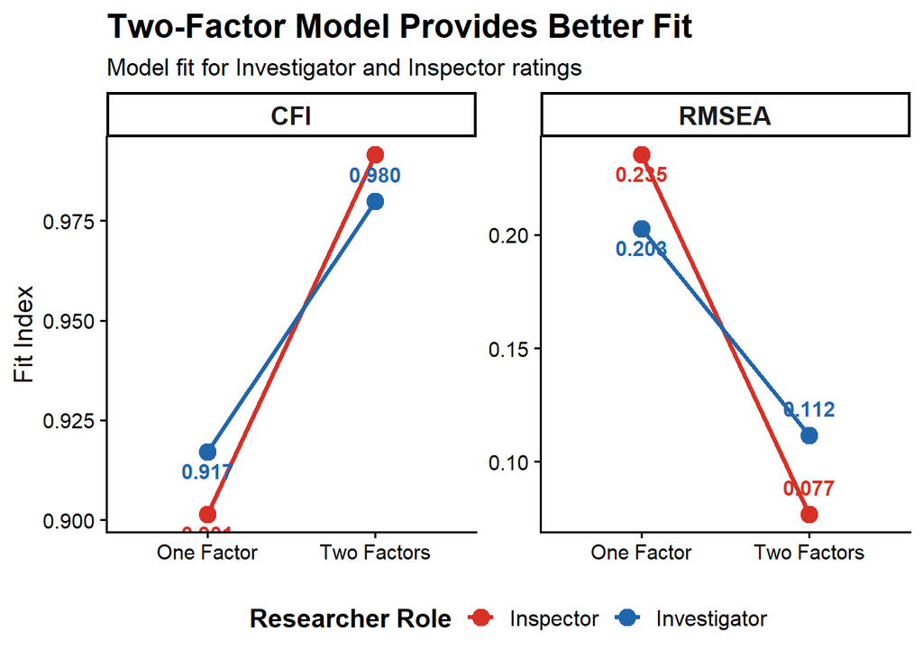

```r
# FIGURE: One-Factor vs. Two-Factor Model Fit
# Investigator vs. Inspector


library(ggplot2)
library(dplyr)
library(tidyr)

# Create model comparison data
model_comparison <- data.frame(
  Role = rep(c("Investigator", "Inspector"), each = 2),
  Model = rep(c("One Factor", "Two Factors"), 2),

  CFI = c(
    fitMeasures(investigator_one, "cfi"),
    fitMeasures(investigator_two, "cfi"),
    fitMeasures(inspector_one, "cfi"),
    fitMeasures(inspector_two, "cfi")
  ),

  RMSEA = c(
    fitMeasures(investigator_one, "rmsea"),
    fitMeasures(investigator_two, "rmsea"),
    fitMeasures(inspector_one, "rmsea"),
    fitMeasures(inspector_two, "rmsea")
  )
)

# Set order
model_comparison$Model <- factor(
  model_comparison$Model,
  levels = c("One Factor", "Two Factors")
)

# Convert to long format
plot_data <- model_comparison %>%
  pivot_longer(
    cols = c(CFI, RMSEA),
    names_to = "Fit_Index",
    values_to = "Value"
  )

# Plot

ggplot(
  plot_data,
  aes(
    x = Model,
    y = Value,
    group = Role,
    color = Role
  )
) +

  # Lines
  geom_line(linewidth = 1.2) +

  # Points
  geom_point(size = 4) +

  # Value labels
  geom_text(
    aes(
      label = sprintf("%.3f", Value),
      vjust = ifelse(
        Model == "One Factor",
        1.7,
        -1.2
      )
    ),
    size = 4,
    fontface = "bold",
    show.legend = FALSE
  ) +

  # Separate panels for CFI and RMSEA
  facet_wrap(
    ~ Fit_Index,
    scales = "free_y"
  ) +

  # Labels
  labs(
    title = "Two-Factor Model Provides Better Fit",
    subtitle = "Model fit for Investigator and Inspector ratings",
    x = NULL,
    y = "Fit Index",
    color = "Researcher Role"
  ) +

  # Colors
  scale_color_manual(
    values = c(
      "Investigator" = "#2166AC",
      "Inspector" = "#D73027"
    )
  ) +

  # Theme
  theme_classic(base_size = 14) +

  theme(
    plot.title = element_text(
      face = "bold",
      size = 18
    ),

    plot.subtitle = element_text(
      size = 13
    ),

    strip.text = element_text(
      face = "bold",
      size = 14
    ),

    legend.position = "bottom",

    legend.title = element_text(
      face = "bold"
    ),

    legend.text = element_text(
      size = 12
    )
  )
```

```r
# Install afex if it is not already installed
if (!requireNamespace("afex", quietly = TRUE)) {
  install.packages("afex")
}

# Load package
library(afex)
```

#exploratory anovas

#INTEGRITYANOVA

```r
#Exploratory ANOVAs: Severity as categorical

# INTEGRITY ANOVA
# Role = within-subjects
# Severity = within-subjects

integrity_anova_dat = tl_dat %>%
  mutate(
    Role = factor(
      role,
      levels = c("investigator", "inspector"),
      labels = c("Investigator", "Inspector")
    ),
    Severity = factor(
      severity_num,
      levels = c(0, 1, 2),
      labels = c("Minor", "Moderate", "Major")
    ),
    Participant = factor(responseid)
  )

integrity_rm_anova = aov_ez(
  id = "Participant",
  dv = "Integrity",
  data = integrity_anova_dat,
  within = c("Role", "Severity"),
  type = 3,
  fun_aggregate = mean
)
integrity_rm_anova
```

```
## Anova Table (Type 3 tests)
##
## Response: Integrity
##          Effect           df  MSE           F  ges p.value
## 1          Role       1, 441 1.34 2781.12 *** .710   <.001
## 2      Severity 1.75, 773.70 0.34  279.61 *** .099   <.001
## 3 Role:Severity 1.89, 832.06 0.48  367.16 *** .179   <.001
## ---
## Signif. codes:  0 '***' 0.001 '**' 0.01 '*' 0.05 '+' 0.1 ' ' 1
##
## Sphericity correction method: GG
```

#LIKEABILITYANOVA

```r
# LIKEABILITY ANOVA
# Role = within-subjects
# Severity = within-subjects


like_anova_dat <- model.frame(L4) %>%
  mutate(
    Role = factor(
      role_ec,
      levels = c(-1, 1),
      labels = c("Investigator", "Inspector")
    ),
    Severity = factor(
      severity_num,
      levels = c(0, 1, 2),
      labels = c("Minor", "Moderate", "Major")
    ),
    Participant = factor(responseid)
  )

like_rm_anova <- aov_ez(
  id = "Participant",
  dv = "likeability",
  data = like_anova_dat,
  within = c("Role", "Severity"),
  type = 3,
  fun_aggregate = mean
)
like_rm_anova
```

```
## Anova Table (Type 3 tests)
##
## Response: likeability
##          Effect           df  MSE          F  ges p.value
## 1          Role       1, 441 1.82 653.40 *** .386   <.001
## 2      Severity 1.91, 840.59 0.33  78.58 *** .025   <.001
## 3 Role:Severity 1.94, 855.71 0.53 208.94 *** .103   <.001
## ---
## Signif. codes:  0 '***' 0.001 '**' 0.01 '*' 0.05 '+' 0.1 ' ' 1
##
## Sphericity correction method: GG
```

#TRUENESSANOVA

```r
# TRUENESS ANOVA
# Severity = within-subjects


trueness_anova_dat <- trueness_dat %>%
  mutate(
    Severity = factor(
      severity_num,
      levels = c(0, 1, 2),
      labels = c("Minor", "Moderate", "Major")
    ),
    Participant = factor(responseid)
  )

trueness_rm_anova <- aov_ez(
  id = "Participant",
  dv = "trueness",
  data = trueness_anova_dat,
  within = "Severity",
  type = 3,
  fun_aggregate = mean
)
trueness_rm_anova
```

```
## Anova Table (Type 3 tests)
##
## Response: trueness
##     Effect           df  MSE          F  ges p.value
## 1 Severity 1.97, 869.43 0.67 387.70 *** .321   <.001
## ---
## Signif. codes:  0 '***' 0.001 '**' 0.01 '*' 0.05 '+' 0.1 ' ' 1
##
## Sphericity correction method: GG
```

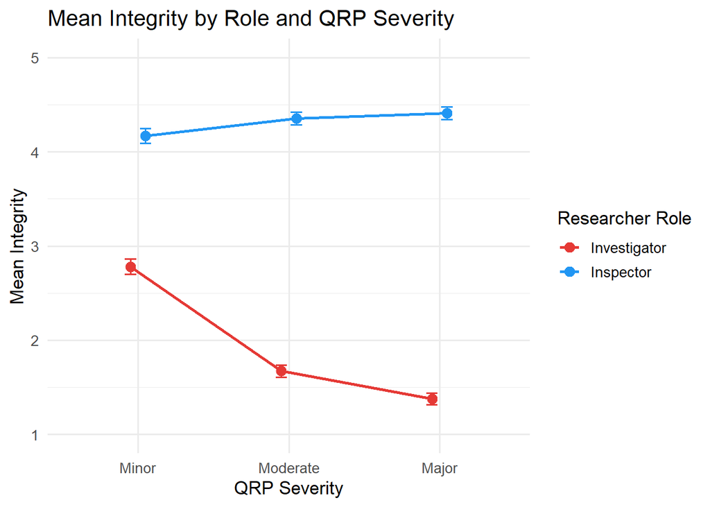

```r
### Raw means for Integrity and Likeability

plot_raw_means = function(data, outcome, outcome_label) {

  raw_df = data %>%
    group_by(role, severity_num) %>%
    summarise(
      n = sum(!is.na(.data[[outcome]])),
      mean = mean(.data[[outcome]], na.rm = TRUE),
      sd = sd(.data[[outcome]], na.rm = TRUE),
      se = sd / sqrt(n),
      lower.CL = mean - qt(0.975, df = n - 1) * se,
      upper.CL = mean + qt(0.975, df = n - 1) * se,
      .groups = "drop"
    ) %>%
    mutate(
      Severity = factor(
        severity_num,
        levels = c(0, 1, 2),
        labels = c("Minor", "Moderate", "Major")
      ),
      Role = factor(
        role,
        levels = c("investigator", "inspector"),
        labels = c("Investigator", "Inspector")
      )
    )

  ggplot(
    raw_df,
    aes(
      x = Severity,
      y = mean,
      color = Role,
      group = Role
    )
  ) +
    geom_line(linewidth = 1, position = position_dodge(width = 0.2)) +
    geom_point(size = 3, position = position_dodge(width = 0.2)) +
    geom_errorbar(
      aes(ymin = lower.CL, ymax = upper.CL),
      width = 0.15,
      position = position_dodge(width = 0.2)
    ) +
    scale_color_manual(
      values = c(
        "Investigator" = "#E53935",
        "Inspector" = "#2196F3"
      )
    ) +
    labs(
      title = paste("Mean", outcome_label, "by Role and QRP Severity"),
      y = paste("Mean", outcome_label),
      x = "QRP Severity",
      color = "Researcher Role"
    ) +
    theme_minimal(base_size = 13) +
    coord_cartesian(ylim = c(1, 5))
}

# Integrity
plot_raw_means(tl_dat, "Integrity", "Integrity")
```

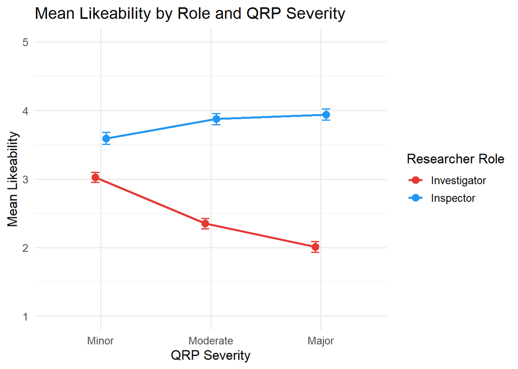

```r
# Likeability
plot_raw_means(tl_dat, "likeability", "Likeability")
```

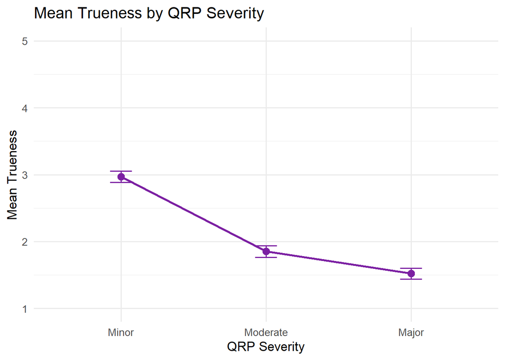

```r
### Raw means for Trueness

plot_raw_trueness = function(data) {

  raw_df = data %>%
    group_by(severity_num) %>%
    summarise(
      n = sum(!is.na(trueness)),
      mean = mean(trueness, na.rm = TRUE),
      sd = sd(trueness, na.rm = TRUE),
      se = sd / sqrt(n),
      lower.CL = mean - qt(0.975, df = n - 1) * se,
      upper.CL = mean + qt(0.975, df = n - 1) * se,
      .groups = "drop"
    ) %>%
    mutate(
      Severity = factor(
        severity_num,
        levels = c(0, 1, 2),
        labels = c("Minor", "Moderate", "Major")
      )
    )

  ggplot(
    raw_df,
    aes(
      x = Severity,
      y = mean,
      group = 1
    )
  ) +
    geom_line(linewidth = 1, color = "#7B1FA2") +
    geom_point(size = 3, color = "#7B1FA2") +
    geom_errorbar(
      aes(ymin = lower.CL, ymax = upper.CL),
      width = 0.15,
      color = "#7B1FA2"
    ) +
    labs(
      title = "Mean Trueness by QRP Severity",
      y = "Mean Trueness",
      x = "QRP Severity"
    ) +
    theme_minimal(base_size = 13) +
    coord_cartesian(ylim = c(1, 5))
}

plot_raw_trueness(trueness_dat)
```